# P6 Linear Regression for Binary, Continuous and Event-Time Outcomes

#### 2.2.2.2 Binary + Continuous Predictor

We will use the transmission type and qsec as predictors.

Lets produce a scatter plot:

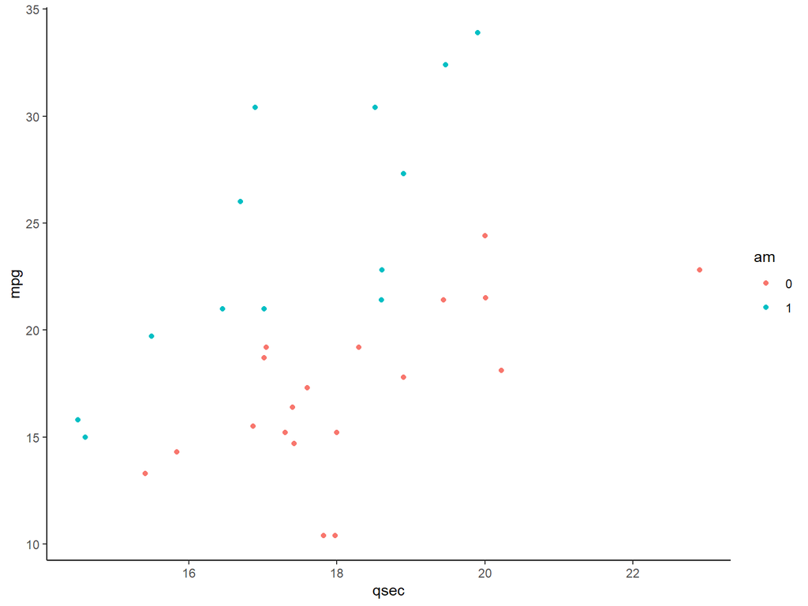

```r
mtcars %>% ggplot(aes(x = qsec, y = mpg, color = am)) +
  geom_point() +
  theme_classic()
```

We see that the transmission splits the data in a group with lower values (automatic transmission) and higher values (manual transmission) when adjusted for qsec.  
We can also see from this plot that am is associated to mpg since cars with automatic transmission have generally lower mpg values.  
It is not very clear from this plot if am also has a certain association with qsec. This is interesting to know in order to assess if there could be confounding of the association between qsec and mpg by am.  
Lets produce a boxplot to inspect the distributions of qsec of the two transmission types:

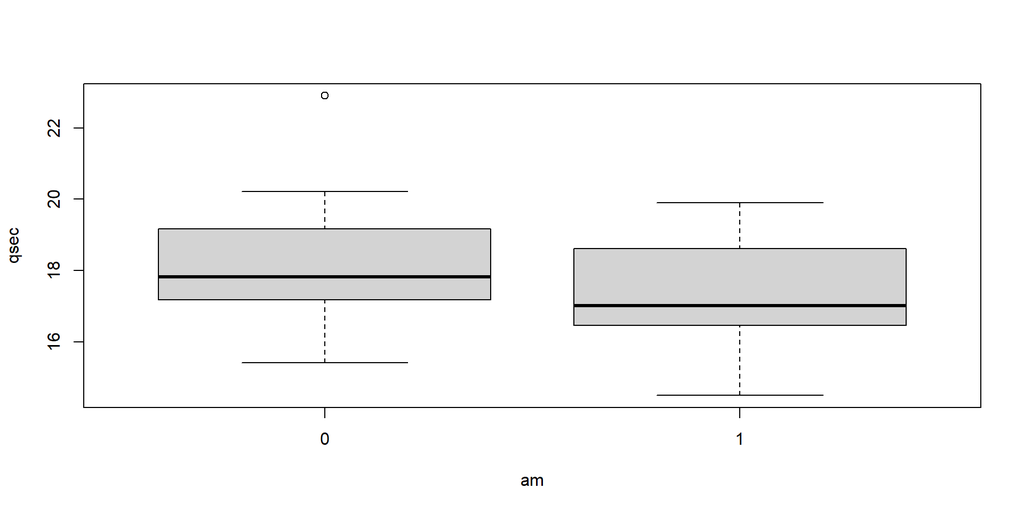

```r
boxplot(data = mtcars, qsec ~ am)
```

We see that the cars with manual transmission have generally a bit lower values for qsec.  
However there is a lot of overlap. Nevertheless there could be confounding by am, as it seems there is an association between am and mpg as well as qsec.

In order to assess this further we can compare the slope of the crude association between qsec and mpg and compare it to the slope adjusted for transmission type.

We had already fit a model with just qsec as predictor variable for mpg:

```r
summary(slr3)
```

```
##
## Call:
## lm(formula = mpg ~ qsec, data = mtcars)
##
## Residuals:
##     Min      1Q  Median      3Q     Max
## -9.8760 -3.4539 -0.7203  2.2774 11.6491
##
## Coefficients:
##             Estimate Std. Error t value Pr(>|t|)
## (Intercept)  -5.1140    10.0295  -0.510   0.6139
## qsec          1.4121     0.5592   2.525   0.0171 *
## ---
## Signif. codes:  0 '***' 0.001 '**' 0.01 '*' 0.05 '.' 0.1 ' ' 1
##
## Residual standard error: 5.564 on 30 degrees of freedom
## Multiple R-squared:  0.1753, Adjusted R-squared:  0.1478
## F-statistic: 6.377 on 1 and 30 DF,  p-value: 0.01708
```

The 95% CI for the slope is calculated as follows:

```r
#lci
slr3$coefficients[[2]] - qt(p = 0.975, df = 30)*0.5592
```

```
## [1] 0.2700861
```

```r
#uci
slr3$coefficients[[2]] + qt(p = 0.975, df = 30)*0.5592
```

```
## [1] 2.554164
```

The slope that describes the increase of the mean mpg with an increase of one qsec is 1.41 [0.27, 2.55].

Lets fit a linear model using am as well to get the slope adjusted for am:

```r
mlr2 <- lm(data = mtcars, mpg ~ am + qsec)
summary(mlr2)
```

```
##
## Call:
## lm(formula = mpg ~ am + qsec, data = mtcars)
##
## Residuals:
##     Min      1Q  Median      3Q     Max
## -6.3447 -2.7699  0.2938  2.0947  6.9194
##
## Coefficients:
##             Estimate Std. Error t value Pr(>|t|)
## (Intercept) -18.8893     6.5970  -2.863  0.00771 **
## am1           8.8763     1.2897   6.883 1.46e-07 ***
## qsec          1.9819     0.3601   5.503 6.27e-06 ***
## ---
## Signif. codes:  0 '***' 0.001 '**' 0.01 '*' 0.05 '.' 0.1 ' ' 1
##
## Residual standard error: 3.487 on 29 degrees of freedom
## Multiple R-squared:  0.6868, Adjusted R-squared:  0.6652
## F-statistic:  31.8 on 2 and 29 DF,  p-value: 4.882e-08
```

The 95% CI for the slope is calculated as follows:

```r
#lci
mlr2$coefficients[[3]] - qt(p = 0.975, df = 29)*0.3601
```

```
## [1] 1.245382
```

```r
#uci
mlr2$coefficients[[3]] + qt(p = 0.975, df = 29)*0.3601
```

```
## [1] 2.718357
```

The slope that describes the increase of the mean mpg with an increase of one qsec adjusted for transmission type is 1.98 [1.25, 2.72].  
The 95% CIs for the two slopes overlap, therefore we cannot say that there is a statistically significant difference between the two.

We can now do the same for am:

```r
#lci crude
slr1$coefficients[[2]] - qt(p = 0.975, df = 30)*1.764
```

```
## [1] 3.642371
```

```r
#uci crude
slr1$coefficients[[2]] + qt(p = 0.975, df = 30)*1.764
```

```
## [1] 10.84751
```

```r
#lci adjusted
mlr2$coefficients[[2]] - qt(p = 0.975, df = 29)*1.2897
```

```
## [1] 6.238598
```

```r
#uci adjusted
mlr2$coefficients[[2]] + qt(p = 0.975, df = 29)*1.2897
```

```
## [1] 11.51406
```

Present the results:

```r
cbind(c("variable", "qsec", "am"),
  c("unadjusted", "1.41 [0.27, 2.55]", "7.24 [3.64, 10.85]" ),
  c("adjusted", "1.98 [1.25, 2.72]", "8.88 [6.24, 11.51]")) %>% kable()
```

| variable | unadjusted | adjusted |
| --- | --- | --- |
| qsec | 1.41 [0.27, 2.55] | 1.98 [1.25, 2.72] |
| am | 7.24 [3.64, 10.85] | 8.88 [6.24, 11.51] |

The 95% CIs for the adjusted and adjusted slopes for am overlap as well. Therefore the difference is not statistically significant at an alpha of 0.05 and we cannot say for sure that there was confounding.

We can visually represent the comparison of the crude model for qsec with the model adjusted for am, by plotting them in the same graph.  
The blue line represents the crude model and the red and green lines the adjusted model:

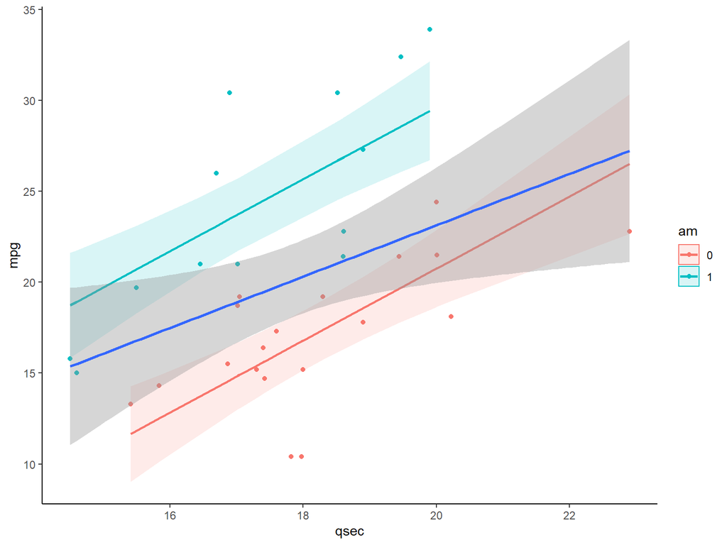

```r
#extract predictions from model
mtcars_mlr2 <- mtcars
mtcars_mlr2 <- predict(mlr2, interval = "confidence") %>%
  data.frame() %>%
  cbind(., mtcars_mlr2)

ggplot(data = mtcars_mlr2, aes(x = qsec, y = mpg)) +
  geom_point(aes(color = am)) +
  geom_ribbon(aes(ymin = lwr, ymax = upr, fill = am, color = NULL), alpha = .15) +
  geom_line(aes(y = fit, color = am), size = 1) +
  geom_smooth(method = "lm", formula = y ~ x) +
  theme_classic()
```

We see that there is overlap in the 95% CIs between the two models, which tells us that the difference is not statistically significant.

However the R squared of the model we fit here is better then those for both the individual models (0.67 vs. 0.34 for only am and 0.15 for only qsec). So the combination definitely adds some information. The difference in slopes might just not statistically significant due to the small sample size.

We can also investigate if there is effect modification of the association between qsec and mpg by am. Meaning the association of qsec with mpg could be different for automatic and manual transmission.  
Maybe this is more likely here, since am is definitely more related to mpg than qsec (for effect modification only an association with the outcome is necessary).

We can investigate this visually by showing a plot with separate linear model fits for cars with automatic and manual transmission as well as the crude model for qsec:

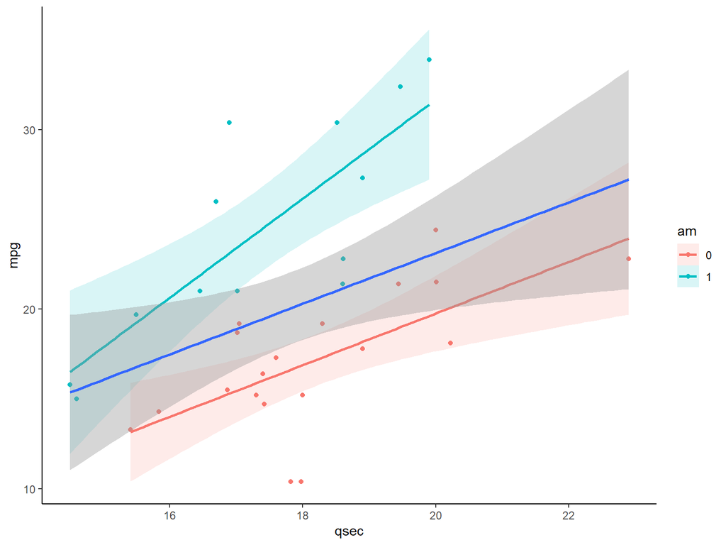

```r
mtcars %>% ggplot(aes(x = qsec, y = mpg)) +
  geom_point(aes(color = am)) +
  geom_smooth(aes(color = am, fill = am), method = "lm", alpha = .15) +
  geom_smooth(method = "lm", formula = y ~ x) +
  theme_classic()
```

We already see that the separate models for the two groups differ in slope as well as in their intercept and their 95% CIs hardly overlap. However their 95% CIs again overlap with the 95% CI for the crude model.  
This tells us that the differences of the slopes for the separate models to the crude model are not statistically significant.

Even if the slopes of the separate models are not significantly different, it is still obvious when visually comparing the fit of the models, that the adjusted model as well as the two separate models per transmission type fit the data better, then the crude model.  
Therefore their result can be considered relevant and the difference might be statistically significant with a bigger sample.

When comparing the plots with the two different slopes to the adjusted model above visually, especially the fit for cars with manual transmission is better. Therefore the model with interaction terms could be preferable.

In a case where there is effect modification like here, we have the choice to either present the two models separately, or fit one model with an interaction term as follows:

```r
mlr3 <- lm(data = mtcars, mpg ~ am + qsec + am*qsec)
summary(mlr3)
```

```
##
## Call:
## lm(formula = mpg ~ am + qsec + am * qsec, data = mtcars)
##
## Residuals:
##     Min      1Q  Median      3Q     Max
## -6.4551 -1.4331  0.1918  2.2493  7.2773
##
## Coefficients:
##             Estimate Std. Error t value Pr(>|t|)
## (Intercept)  -9.0099     8.2179  -1.096  0.28226
## am1         -14.5107    12.4812  -1.163  0.25481
## qsec          1.4385     0.4500   3.197  0.00343 **
## am1:qsec      1.3214     0.7017   1.883  0.07012 .
## ---
## Signif. codes:  0 '***' 0.001 '**' 0.01 '*' 0.05 '.' 0.1 ' ' 1
##
## Residual standard error: 3.343 on 28 degrees of freedom
## Multiple R-squared:  0.722,  Adjusted R-squared:  0.6923
## F-statistic: 24.24 on 3 and 28 DF,  p-value: 6.129e-08
```

This has the advantage, that we can fit one model using all the data and it also provides a formal hypothesis test, to determine if the effect modification is statistically significant.  
Here this is not the case, as the interaction term (am1:qsec) is not significantly different from zero.  
Compared to the adjusted model here the intercept and the coefficient for am are no longer significantly different from zero. However the adjusted R squared is a bit better (0.6923 instead of 0.6652)

The way to go here would probably be to collect more data if possible or to include more variables that might modify or confound the the association between qsec and mpg.

**Check Model Assumptions**

- Linearity

Here we have to assess the adjusted linearity between the predictor variables and the outcome. We can do this via inspecting an adjusted variable plot produced via the function car::avPlots. For the model without interaction term:

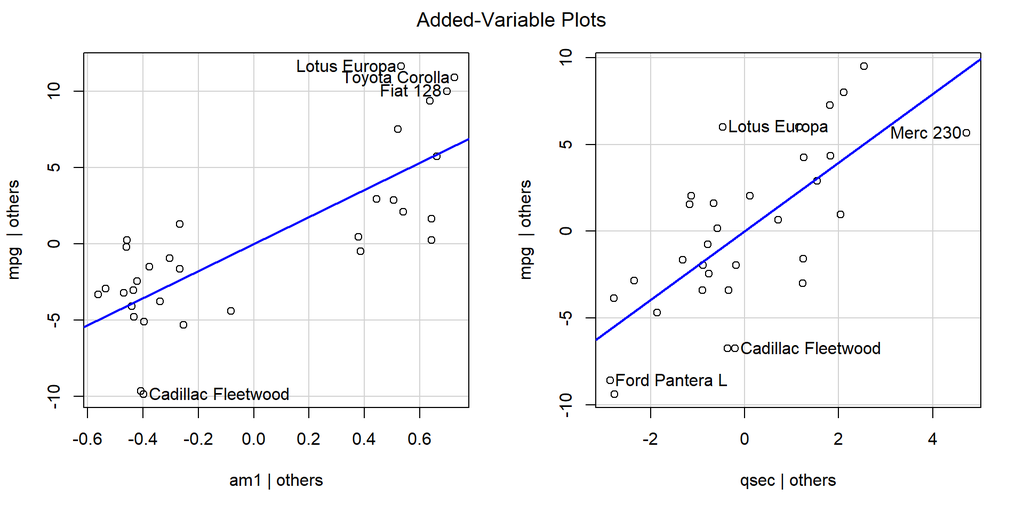

```r
avPlots(mlr2)
```

and with the interaction term:

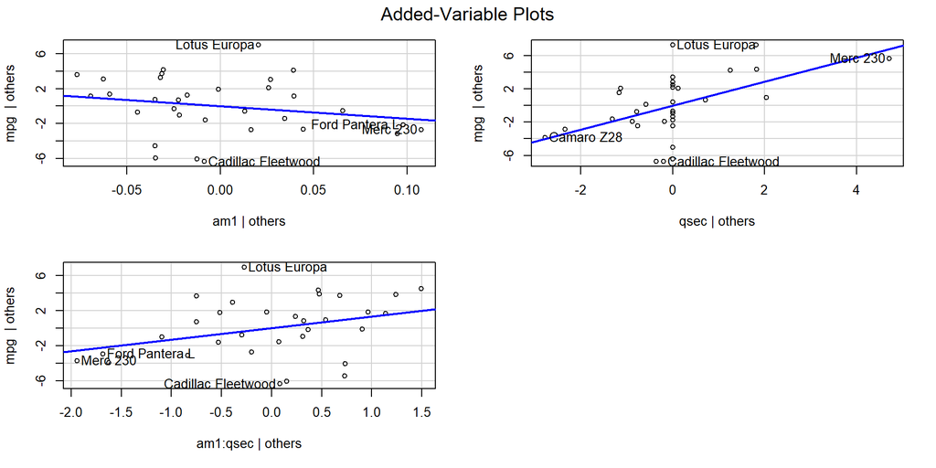

```r
avPlots(mlr3)
```

All plots show a reasonably linear relation. The assumption is therefore fulfilled.

- Homoscedasticity

To assess homoscedasticity we can look at a plot of the fitted value versus the sqrt of the standardized residuals.

Model without interaction term:

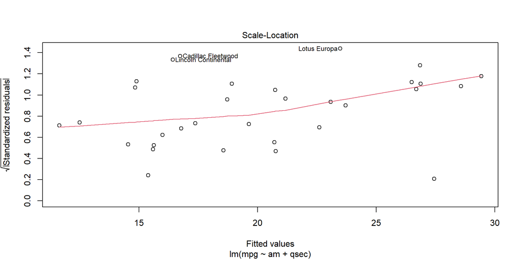

```r
plot(mlr2, which = 3)
```

The residuals increase a bit with higher fitted values.

Model with interaction term:

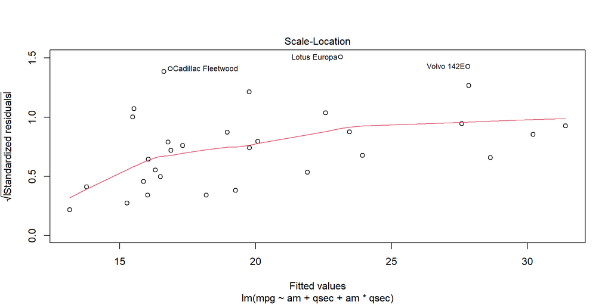

```r
plot(mlr3, which = 3)
```

Looks ok. The drop of to the left is only due to two quite small values on the left.

- Extreme Values / Outliers

We can look at the Cooks distance to asses this.

Model without interaction term:

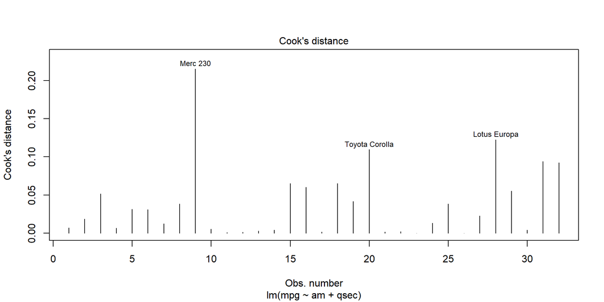

```r
plot(mlr2, which = 4)
```

This looks ok.

Model with interaction term:

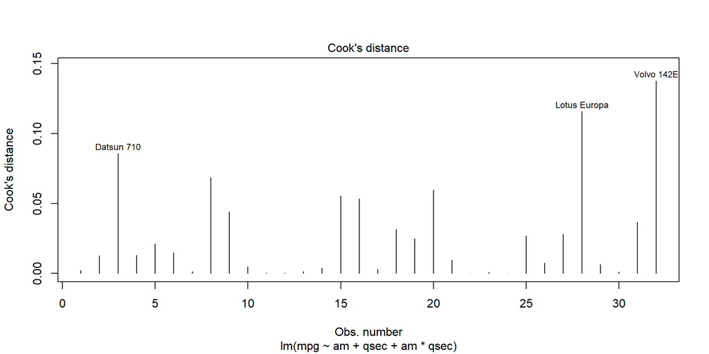

```r
plot(mlr3, which = 4)
```

Looks ok as well.

- Normality

We can look at a QQ plot to determine if the residuals are normally distributed.

Model without interaction term:

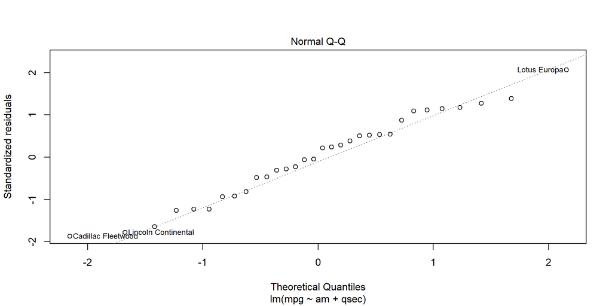

```r
plot(mlr2, which = 2)
```

Looks more or less ok, only one point that is a bit off (15).

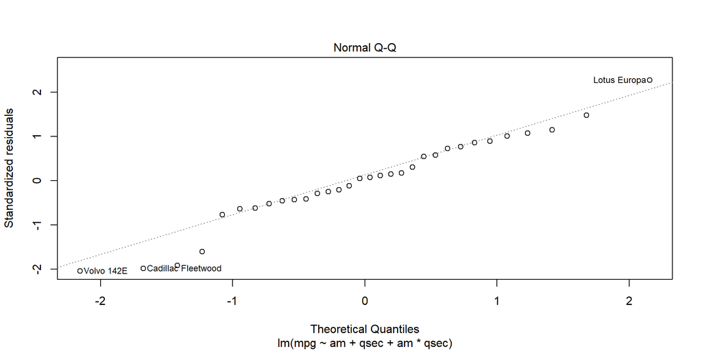

```r
plot(mlr3, which = 2)
```

Looks ok as well, but there are three point s that are a bit off.

#### 2.2.2.3 Adding another variable

We will now add cyl as well to the model:

```r
mlr4 <- lm(data = mtcars, mpg ~ am + qsec + cyl)
summary(mlr4)
```

```
##
## Call:
## lm(formula = mpg ~ am + qsec + cyl, data = mtcars)
##
## Residuals:
##     Min      1Q  Median      3Q     Max
## -6.0358 -1.2180 -0.1731  1.7725  5.9494
##
## Coefficients:
##             Estimate Std. Error t value Pr(>|t|)
## (Intercept)  16.4586    13.1996   1.247  0.22314
## am1           3.6113     2.1115   1.710  0.09868 .
## qsec          0.3960     0.6233   0.635  0.53055
## cyl6         -5.3827     1.9727  -2.729  0.01105 *
## cyl8         -8.5165     2.8485  -2.990  0.00589 **
## ---
## Signif. codes:  0 '***' 0.001 '**' 0.01 '*' 0.05 '.' 0.1 ' ' 1
##
## Residual standard error: 3.107 on 27 degrees of freedom
## Multiple R-squared:  0.7686, Adjusted R-squared:  0.7343
## F-statistic: 22.42 on 4 and 27 DF,  p-value: 2.99e-08
```

The coefficients for the intercept, am = 1 and qsec are no longer statistically significant. As discussed above for the intercept this is not really a problem, since it represents here cars with am = 0, cyl = 4 and qsec = 0 (which is quite far off of the lowest value for qsec in the dataset.)

The adjusted R squared improved compared to the model including only am and qsec, but is around the same for the model including transmission type and cyl. This would indicate that qsec does not add much to the model here and the simpler model should be preferred.

### 2.2.3 Finding The Best Model

Since in this data set we have several more variables, we can now try to find the combination of variables, which gives us the “best” model.

The criterium to choose the best model depends on our goal (e.g. prediction vs. inference)

We will first do some reformatting

```r
mtcars$vs <- as.character(mtcars$vs)
mtcars$am <- as.character(mtcars$am)

#give more descriptive values for vs and am
mtcars <- mtcars %>% mutate(vs = replace(mtcars$vs, vs == 0, "v_shaped")) %>%
        mutate(vs = replace(.$vs, vs == 1, "straight"))
mtcars <- mtcars %>% mutate(am = replace(mtcars$am, am == 0, "automatic")) %>%
        mutate(am = replace(.$am, am == 1, "manual"))

#convert factors to factors:
mtcars$vs <- as.factor(mtcars$vs)
mtcars$gear <- as.factor(mtcars$gear)
mtcars$carb <- as.factor(mtcars$carb)
mtcars$am <- as.factor(mtcars$am)
```

Show structure:

```r
str(mtcars)
```

```
## 'data.frame':    32 obs. of  11 variables:
##  $ mpg : num  21 21 22.8 21.4 18.7 18.1 14.3 24.4 22.8 19.2 ...
##  $ cyl : Factor w/ 3 levels "4","6","8": 2 2 1 2 3 2 3 1 1 2 ...
##  $ disp: num  160 160 108 258 360 ...
##  $ hp  : num  110 110 93 110 175 105 245 62 95 123 ...
##  $ drat: num  3.9 3.9 3.85 3.08 3.15 2.76 3.21 3.69 3.92 3.92 ...
##  $ wt  : num  2.62 2.88 2.32 3.21 3.44 ...
##  $ qsec: num  16.5 17 18.6 19.4 17 ...
##  $ vs  : Factor w/ 2 levels "straight","v_shaped": 2 2 1 1 2 1 2 1 1 1 ...
##  $ am  : Factor w/ 2 levels "automatic","manual": 2 2 2 1 1 1 1 1 1 1 ...
##  $ gear: Factor w/ 3 levels "3","4","5": 2 2 2 1 1 1 1 2 2 2 ...
##  $ carb: Factor w/ 6 levels "1","2","3","4",..: 4 4 1 1 2 1 4 2 2 4 ...
```

We will now use the best subset method to find the best combination of variables to fit our Model. For this we will use the olsrr::ols_step_best_subset function.

Use the function:

```r
#fit model
bestsub_model <- lm(mpg ~ ., data = mtcars)
#find best subsets
bestsub <- ols_step_best_subset(bestsub_model)
#select and print relevant information from output
cbind(n_variables = bestsub[, "n"],
      var_included = bestsub[, "predictors"],
      adj_R2 = round(bestsub[, "adjr"], digits = 3),
      AIC = round(bestsub[, "aic"], digits = 3)) %>%
        kable()
```

| n_variables | var_included | adj_R2 | AIC |
| --- | --- | --- | --- |
| 1 | wt | 0.745 | 166.029 |
| 2 | cyl wt | 0.82 | 156.622 |
| 3 | cyl hp wt | 0.836 | 154.469 |
| 4 | cyl hp wt am | 0.84 | 154.467 |
| 5 | cyl hp wt gear carb | 0.807 | 164.099 |
| 6 | cyl disp hp wt gear carb | 0.814 | 163.197 |
| 7 | cyl disp hp wt vs gear carb | 0.81 | 164.188 |
| 8 | cyl disp hp drat wt vs gear carb | 0.802 | 165.639 |
| 9 | cyl disp hp drat wt qsec vs gear carb | 0.791 | 167.518 |
| 10 | cyl disp hp drat wt qsec vs am gear carb | 0.779 | 169.215 |

The output above shows us which variables where included in the best model per “model size” (how many variables are included) as well as the adjusted R squared and AIC for each of these models.

Which criterion we use to select the “best” model depends on our intention. For example, if our intention is prediction, we would likely choose the model with the highest adjusted R squared.  
We will use the adjusted R squared as a guide to indicate to us the most promising models. We will then have a closer look at them an the variables they include.

We get the best adjusted R squared for the model including 4 variables. The adjusted R squared for the model including three variables however is very close. The AIC indicates to us these two models as being the most promising as well.

Both these models include:  
- cyl (= Number of cylinders)  
- hp (= Gross horsepower)  
- wt (= Weight (1000 lbs))

The model including 4 variables additionally contains am (= Transmission type).

Plot hp and wt against mpg respectively using color to indicate cyl:

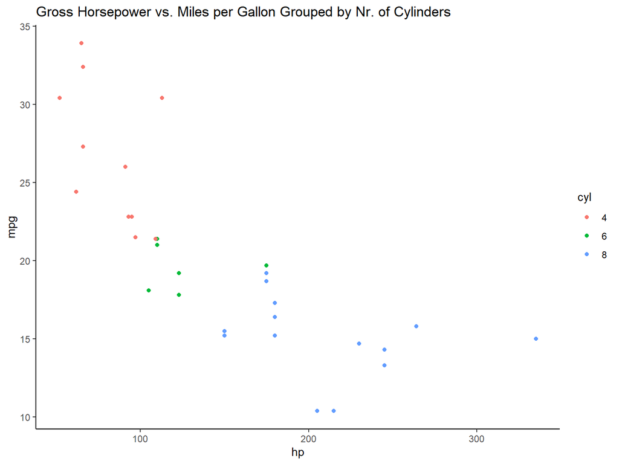

```r
mtcars %>% ggplot(aes(x = hp, y = mpg, color = cyl)) +
        geom_point() +
        ggtitle("Gross Horsepower vs. Miles per Gallon Grouped by Nr. of Cylinders") +
        theme_classic()
```

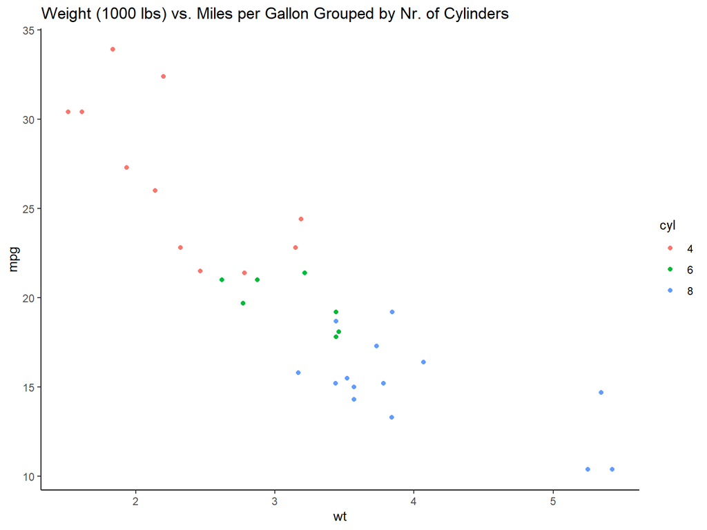

```r
mtcars %>% ggplot(aes(x = wt, y = mpg, color = cyl)) +
        geom_point()+
        ggtitle("Weight (1000 lbs) vs. Miles per Gallon Grouped by Nr. of Cylinders") +
        theme_classic()
```

The relation with mpg looks quite linear for both of the variables. The number of cylinders seems to be associated with mpg, ht and wt indicating that cyl confounds the relationships of ht and wt with mpg (and the other way around). So it makes sense to include them together in a model, instead of fitting separate models for the variables.

In both of the diagrams we can see a certain “diminishing return” for an increase in our variable, meaning the mpg decreases less for high values of weight and horsepower respectively.

From the plot for horsepower vs. mpg we could speculate that an interaction term between hp and cyl could benefit the model fit. We can assess that by imagining a separate linear fit for each cyl number each with a different slope and compare these fits to fits to the groups with the same slope for all the data. Here it seems like fits with different slopes would explain more of the variability.  
However the problem with this would be that we dont really have that much data and it is therefore quite possible that the different slopes of these fits would be just due to noise in the data and not because “the rules change” between the groups (overfitting).

Lets fit a model without interaction term:

```r
bestsub_mod3 <- lm(mpg ~ wt + hp + cyl, data = mtcars)
summary(bestsub_mod3)
```

```
##
## Call:
## lm(formula = mpg ~ wt + hp + cyl, data = mtcars)
##
## Residuals:
##     Min      1Q  Median      3Q     Max
## -4.2612 -1.0320 -0.3210  0.9281  5.3947
##
## Coefficients:
##             Estimate Std. Error t value Pr(>|t|)
## (Intercept) 35.84600    2.04102  17.563 2.67e-16 ***
## wt          -3.18140    0.71960  -4.421 0.000144 ***
## hp          -0.02312    0.01195  -1.934 0.063613 .
## cyl6        -3.35902    1.40167  -2.396 0.023747 *
## cyl8        -3.18588    2.17048  -1.468 0.153705
## ---
## Signif. codes:  0 '***' 0.001 '**' 0.01 '*' 0.05 '.' 0.1 ' ' 1
##
## Residual standard error: 2.44 on 27 degrees of freedom
## Multiple R-squared:  0.8572, Adjusted R-squared:  0.8361
## F-statistic: 40.53 on 4 and 27 DF,  p-value: 4.869e-11
```

And now with an interaction term between cyl and hp:

```r
bestsub_mod3_int <- lm(mpg ~ wt + hp + cyl + cyl*hp, data = mtcars)
summary(bestsub_mod3_int)
```

```
##
## Call:
## lm(formula = mpg ~ wt + hp + cyl + cyl * hp, data = mtcars)
##
## Residuals:
##     Min      1Q  Median      3Q     Max
## -3.1864 -1.4098 -0.4022  1.0186  4.3920
##
## Coefficients:
##              Estimate Std. Error t value Pr(>|t|)
## (Intercept)  41.87732    3.23293  12.953 1.37e-12 ***
## wt           -3.05994    0.68275  -4.482 0.000143 ***
## hp           -0.09947    0.03487  -2.853 0.008576 **
## cyl6         -9.98213    5.76950  -1.730 0.095931 .
## cyl8        -11.72793    4.22507  -2.776 0.010276 *
## hp:cyl6       0.07809    0.05236   1.492 0.148335
## hp:cyl8       0.08602    0.03703   2.323 0.028601 *
## ---
## Signif. codes:  0 '***' 0.001 '**' 0.01 '*' 0.05 '.' 0.1 ' ' 1
##
## Residual standard error: 2.3 on 25 degrees of freedom
## Multiple R-squared:  0.8826, Adjusted R-squared:  0.8544
## F-statistic: 31.32 on 6 and 25 DF,  p-value: 1.831e-10
```

The adjusted R squared increased slightly with the interaction term. When comparing which coefficients are statistically significant we see that in the model with interaction term cyl8:hp “become” significant, where they where not in the model without interaction terms. For cyl6 the opposite happens. The reason for this might be that the data with cyl = 8 is fit better with a separate slope, then the slope with which all of the data would be fit. For the group with cyl = 6 no separate slope is needed to fit the data well.

Here I would probably not include this in the final model due to the risk of over fitting (as discussed above).

In the model without interaction term, the coefficient for hp is not significant (although it is close). I think this could be attributed to the small sample size it would probably “become significant” with a bigger sample.

The coefficient for cyl = 8 is not significant as well. We can check if the variable cyl as a whole is significant by fitting a model without it and performing ANOVA between the models with and without cyl (this constitutes a partial F-test):

```r
bestsub_mod3_wocyl <- lm(mpg ~ wt + hp, data = mtcars)
anova(bestsub_mod3_wocyl, bestsub_mod3)
```

```
## Analysis of Variance Table
##
## Model 1: mpg ~ wt + hp
## Model 2: mpg ~ wt + hp + cyl
##   Res.Df    RSS Df Sum of Sq      F  Pr(>F)
## 1     29 195.05
## 2     27 160.78  2     34.27 2.8776 0.07364 .
## ---
## Signif. codes:  0 '***' 0.001 '**' 0.01 '*' 0.05 '.' 0.1 ' ' 1
```

The result is that there is no significant change by adding cyl as variable (although its close). Its possible that this is also due to the small sample size.

Lets repeat the plots but by using transmission type to color the points:

[figure not shown]

```r
mtcars %>% ggplot(aes(x = hp, y = mpg, color = am)) +
        geom_point() +
        ggtitle("Gross Horsepower vs. Miles per Gallon Grouped by Nr. of Cylinders") +
        theme_classic()
```

[figure not shown]

```r
mtcars %>% ggplot(aes(x = wt, y = mpg, color = am)) +
        geom_point() +
        ggtitle("Weight (1000 lbs) vs. Miles per Gallon Grouped by Nr. of Cylinders") +
        theme_classic()
```

From the plots it seems that transmission type is associated with mpg and wt as well, for hp too, but not as clearly as cyl.

Lets fit the model:

```r
bestsub_mod4 <- lm(mpg ~ wt + hp + cyl + am, data = mtcars)
summary(bestsub_mod4)
```

```
##
## Call:
## lm(formula = mpg ~ wt + hp + cyl + am, data = mtcars)
##
## Residuals:
##     Min      1Q  Median      3Q     Max
## -3.9387 -1.2560 -0.4013  1.1253  5.0513
##
## Coefficients:
##             Estimate Std. Error t value Pr(>|t|)
## (Intercept) 33.70832    2.60489  12.940 7.73e-13 ***
## wt          -2.49683    0.88559  -2.819  0.00908 **
## hp          -0.03211    0.01369  -2.345  0.02693 *
## cyl6        -3.03134    1.40728  -2.154  0.04068 *
## cyl8        -2.16368    2.28425  -0.947  0.35225
## ammanual     1.80921    1.39630   1.296  0.20646
## ---
## Signif. codes:  0 '***' 0.001 '**' 0.01 '*' 0.05 '.' 0.1 ' ' 1
##
## Residual standard error: 2.41 on 26 degrees of freedom
## Multiple R-squared:  0.8659, Adjusted R-squared:  0.8401
## F-statistic: 33.57 on 5 and 26 DF,  p-value: 1.506e-10
```

And perform a partial F-test for am:

```r
anova(bestsub_mod3, bestsub_mod4)
```

```
## Analysis of Variance Table
##
## Model 1: mpg ~ wt + hp + cyl
## Model 2: mpg ~ wt + hp + cyl + am
##   Res.Df    RSS Df Sum of Sq      F Pr(>F)
## 1     27 160.78
## 2     26 151.03  1     9.752 1.6789 0.2065
```

The addition does not change the model in a statistically significant manner.

Due to that and because the difference in adjusted R squared between the two models is quite small, the model without transmission type should probably be preferred, as it explains nearly the same amount of variance in the data with less variables.

#### 2.2.3.1 Log Transform

From the plots of ht and wt against mpg it seems like the model fit could profit from a log transformation of mpg, as then the fit would resemble an exponential decay, which might fit the data better and also take into account that there probably are diminishing returns for mpg, when increasing wt as well as ht.

We can again find the best model with different subsets of variables, but now with log(mpg) as outcome:

```r
#fit model
bestsub_model_log <- lm(log(mpg) ~ ., data = mtcars)
#find best subsets
bestsub_log <- ols_step_best_subset(bestsub_model_log)
#select and print relevant information from output
cbind(n_variables = bestsub_log[, "n"],
      var_included = bestsub_log[, "predictors"],
      adj_R2 = round(bestsub_log[, "adjr"], digits = 3),
      AIC = round(bestsub_log[, "aic"], digits = 3)) %>%
        kable()
```

| n_variables | var_included | adj_R2 | AIC |
| --- | --- | --- | --- |
| 1 | wt | 0.791 | -32.849 |
| 2 | hp wt | 0.86 | -44.79 |
| 3 | wt gear carb | 0.85 | -38.066 |
| 4 | hp wt gear carb | 0.854 | -38.207 |
| 5 | hp drat wt gear carb | 0.852 | -37.238 |
| 6 | cyl disp hp wt gear carb | 0.84 | -34.111 |
| 7 | cyl disp hp drat wt gear carb | 0.836 | -32.941 |
| 8 | cyl disp hp drat wt am gear carb | 0.828 | -31.251 |
| 9 | cyl disp hp drat wt qsec am gear carb | 0.817 | -29.262 |
| 10 | cyl disp hp drat wt qsec vs am gear carb | 0.805 | -27.265 |

The best model found like this is one that includes only ht and wt and its adjusted R squared is better then all of the models fit so far with this data.

Fit and show the model:

```r
bestsub_mod2 <- lm(log(mpg) ~ wt + hp, data = mtcars)
summary(bestsub_mod2)
```

```
##
## Call:
## lm(formula = log(mpg) ~ wt + hp, data = mtcars)
##
## Residuals:
##      Min       1Q   Median       3Q      Max
## -0.18744 -0.07540 -0.02440  0.06244  0.28562
##
## Coefficients:
##               Estimate Std. Error t value Pr(>|t|)
## (Intercept)  3.8291030  0.0686807  55.752  < 2e-16 ***
## wt          -0.2005368  0.0271810  -7.378 3.96e-08 ***
## hp          -0.0015435  0.0003879  -3.979 0.000423 ***
## ---
## Signif. codes:  0 '***' 0.001 '**' 0.01 '*' 0.05 '.' 0.1 ' ' 1
##
## Residual standard error: 0.1114 on 29 degrees of freedom
## Multiple R-squared:  0.8691, Adjusted R-squared:   0.86
## F-statistic: 96.23 on 2 and 29 DF,  p-value: 1.577e-13
```

Both of the coefficients and the intercept are significant.

At least for prediction, this model should be preferred against all the others.

Does it make a difference if we take the logarithm of the outcome or of the predictors?

Fit a model with the logarithms of wt and hp against mpg:

```r
bestsub_mod2_log <- lm(mpg ~ log(wt) + log(hp), data = mtcars)
summary(bestsub_mod2_log)
```

```
##
## Call:
## lm(formula = mpg ~ log(wt) + log(hp), data = mtcars)
##
## Residuals:
##     Min      1Q  Median      3Q     Max
## -2.9422 -1.4293 -0.4933  1.1784  4.9148
##
## Coefficients:
##             Estimate Std. Error t value Pr(>|t|)
## (Intercept)   58.231      4.439  13.119 1.01e-13 ***
## log(wt)      -11.400      1.729  -6.593 3.17e-07 ***
## log(hp)       -5.193      1.155  -4.495 0.000103 ***
## ---
## Signif. codes:  0 '***' 0.001 '**' 0.01 '*' 0.05 '.' 0.1 ' ' 1
##
## Residual standard error: 2.084 on 29 degrees of freedom
## Multiple R-squared:  0.8881, Adjusted R-squared:  0.8804
## F-statistic: 115.1 on 2 and 29 DF,  p-value: 1.611e-14
```

The adjusted R squared improved a bit.

It is unclear why this might be the case. Lets plot log(hp) vs. mpg and hp vs. log(mpg) including regression lines:

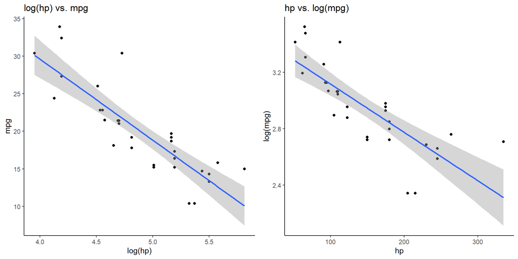

```r
p1 <- mtcars %>% ggplot(aes(x = log(hp), y = mpg)) +
        geom_point() +
        ggtitle("log(hp) vs. mpg") +
        theme_classic() +
        geom_smooth(method = "lm")

p2 <- mtcars %>% ggplot(aes(x = hp, y = log(mpg))) +
        geom_point() +
        ggtitle("hp vs. log(mpg)") +
        theme_classic()+
        geom_smooth(method = "lm")

plot_grid(p1, p2, labels = c("", ""))
```

Maybe the fit for log(hp) vs. mpg is a bit better, but I would probably attribute the improvement in adjusted R squared to noise.

For simplicity I will continue with the model with just mpg logarithmized to look at its diagnostic plots / check the model assumptions:

**Check Model Assumptions**

- Linearity

We already looked at scatter plots for hp vs. log(mpg).

wt vs. log(mpg):

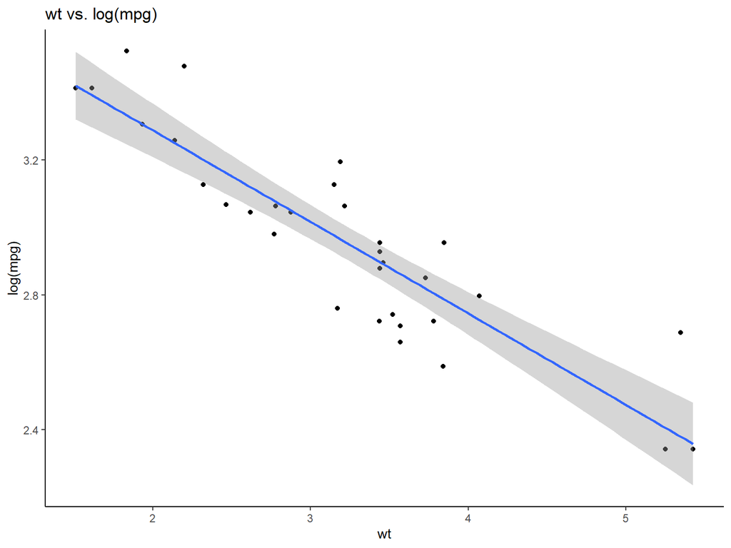

```r
mtcars %>% ggplot(aes(x = wt, y = log(mpg))) +
        geom_point() +
        ggtitle("wt vs. log(mpg)") +
        theme_classic()+
        geom_smooth(method = "lm")
```

There seems to be a reasonably linear relationship between the two variables.

- Homoscedasticity

To assess homoscedasticity we can look at a plot of the fitted value versus the sqrt of the standardized residuals.

Model without interaction term:

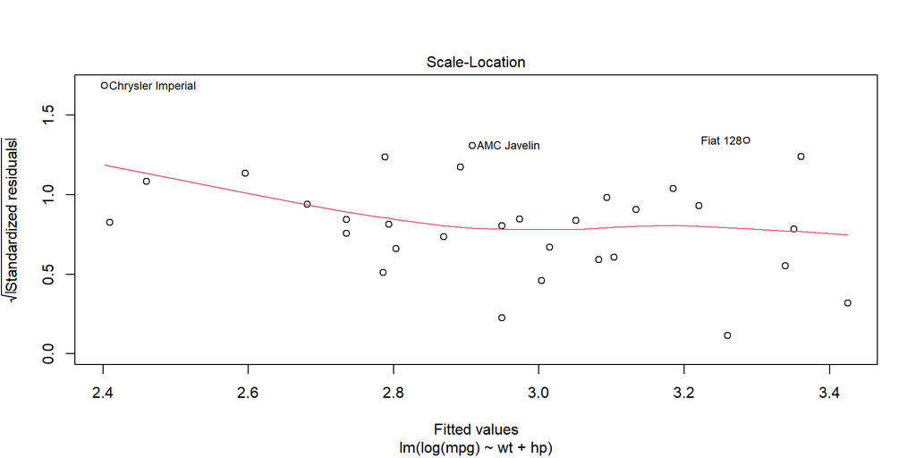

```r
plot(bestsub_mod2, which = 3)
```

Looks ok.

- Extreme Values / Outliers

We can look at the Cooks distance to asses this.

Model without interaction term:

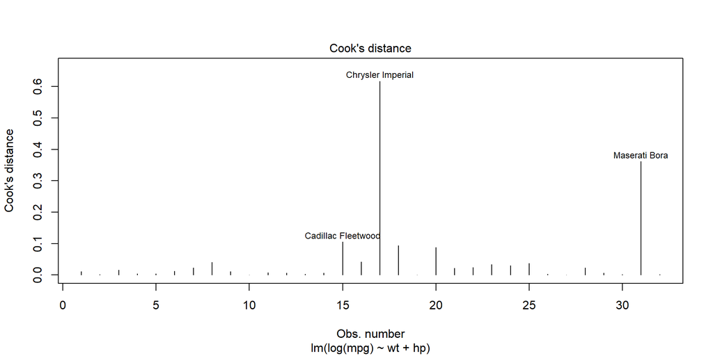

```r
plot(bestsub_mod2, which = 4)
```

There are two values that are quite a bit higher then the rest. Lets look at them in the two scatter plots:

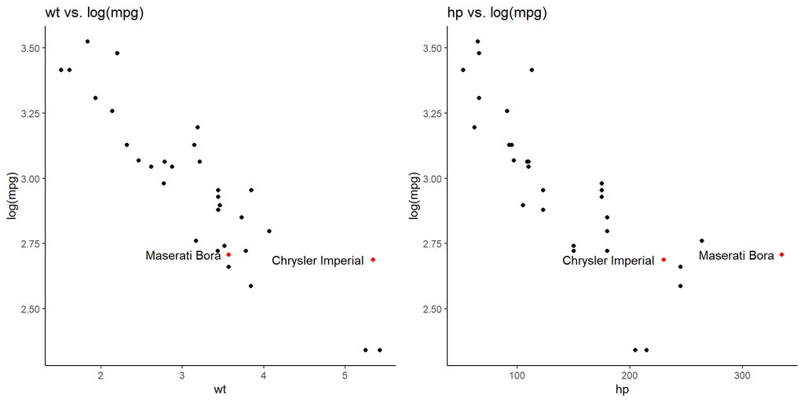

```r
p1 <- mtcars %>% ggplot(aes(x = wt, y = log(mpg),
                      label = rownames(mtcars))) +
        geom_point(color = ifelse(rownames(mtcars) %in% c("Chrysler Imperial", "Maserati Bora"), "red", "black")) +
        ggtitle("wt vs. log(mpg)") +
        theme_classic() +
        geom_text(aes(label = ifelse(rownames(mtcars) %in% c("Chrysler Imperial", "Maserati Bora"), rownames(mtcars), ""),
                      hjust = 1.1))

p2 <- mtcars %>% ggplot(aes(x = hp, y = log(mpg),
                      label = rownames(mtcars))) +
        geom_point(color = ifelse(rownames(mtcars) %in% c("Chrysler Imperial", "Maserati Bora"), "red", "black")) +
        ggtitle("hp vs. log(mpg)") +
        theme_classic() +
        geom_text(aes(label = ifelse(rownames(mtcars) %in% c("Chrysler Imperial", "Maserati Bora"), rownames(mtcars), ""),
                      hjust = 1.1))

plot_grid(p1, p2, labels = c("", ""))
```

They both look to be somewhat off in one of the plots.

- Normality

We can look at a QQ plot to determine if the residuals are normally distributed.

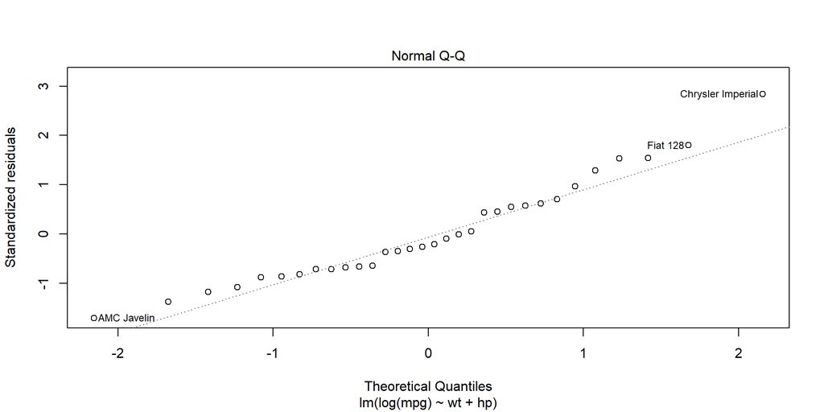

```r
plot(bestsub_mod2, which = 2)
```

Again the Chrysler Imperial looks to be a bit off, otherwise it doesnt look too bad.

We could also repeat the model search with the best subset method on a data set where all the continuous predictors are replaced by their logarithm (and mpg isnt logarithmized).

The problem with this data set is that it is quite small. With more data it might make sense to include more variables, as many of them seem to contain valuable information.

## 2.3 Event-Time Outcome

### 2.3.1 Simple Cox Regression:

We will use the suvival::lung data set, which contains data about “Survival in patients with advanced lung cancer from the North Central Cancer Treatment Group” as well as several possible predictors of survival.

Load in data and show structure:

```r
lung <- survival::lung
str(lung)
```

```
## 'data.frame':    228 obs. of  10 variables:
##  $ inst     : num  3 3 3 5 1 12 7 11 1 7 ...
##  $ time     : num  306 455 1010 210 883 ...
##  $ status   : num  2 2 1 2 2 1 2 2 2 2 ...
##  $ age      : num  74 68 56 57 60 74 68 71 53 61 ...
##  $ sex      : num  1 1 1 1 1 1 2 2 1 1 ...
##  $ ph.ecog  : num  1 0 0 1 0 1 2 2 1 2 ...
##  $ ph.karno : num  90 90 90 90 100 50 70 60 70 70 ...
##  $ pat.karno: num  100 90 90 60 90 80 60 80 80 70 ...
##  $ meal.cal : num  1175 1225 NA 1150 NA ...
##  $ wt.loss  : num  NA 15 15 11 0 0 10 1 16 34 ...
```

Define the factor variables sex and ph.ecog as such:

```r
lung <- lung %>% mutate(sex = as.factor(sex),
                ph.ecog = as.factor(ph.ecog))
```

Create a survival object:

```r
surv_lung <- Surv(lung$time, lung$status)
```

How many died, how many where censored? (2 = dead)

```r
table(lung$status)
```

```
##
##   1   2
##  63 165
```

Kaplan-Meier Plot for whole sample:

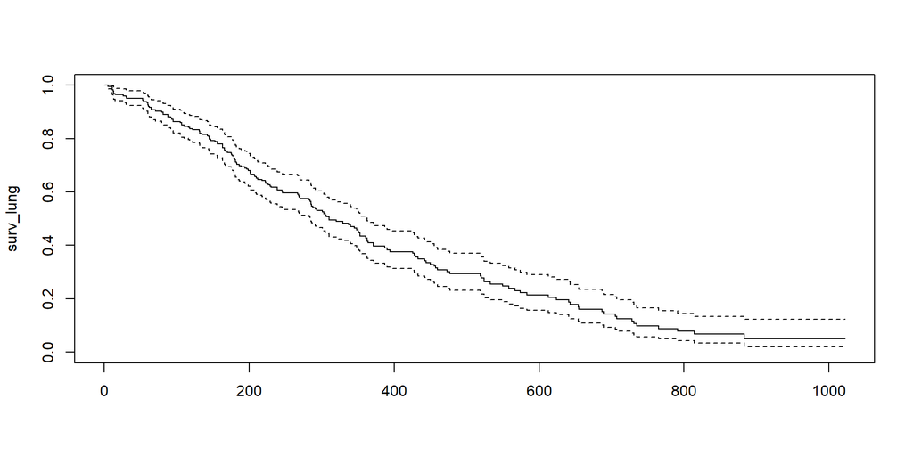

```r
plot(surv_lung ~ 1, )
```

#### 2.3.1.1 Binary Predictor Variable

We will use the sex of the patient as predictor.

Produce a kaplan-meier plot for male and female patients:

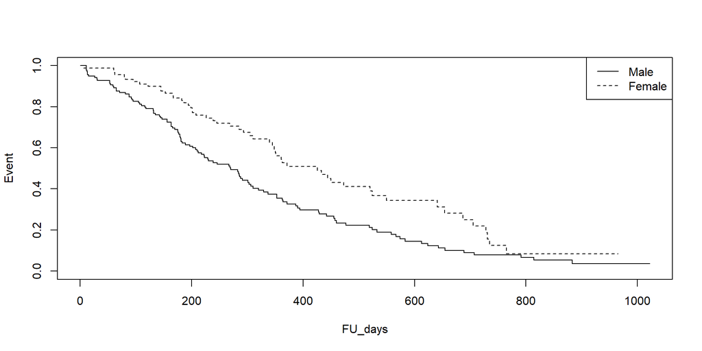

```r
plot(survfit(surv_lung ~ lung$sex),
     lty = c("solid", "dashed"),
     xlab = "FU_days",
     ylab = "Event")

legend("topright",
       c("Male", "Female"),
       lty = c("solid", "dashed"))
```

Females seem to survive generally longer then males, after around 800 days the the females “catch up”.

Fit a Cox model for sex as predictor variable:

```r
coxrm_1 <- coxph(surv_lung ~ lung$sex)
summary(coxrm_1)
```

```
## Call:
## coxph(formula = surv_lung ~ lung$sex)
##
##   n= 228, number of events= 165
##
##              coef exp(coef) se(coef)      z Pr(>|z|)
## lung$sex2 -0.5310    0.5880   0.1672 -3.176  0.00149 **
## ---
## Signif. codes:  0 '***' 0.001 '**' 0.01 '*' 0.05 '.' 0.1 ' ' 1
##
##           exp(coef) exp(-coef) lower .95 upper .95
## lung$sex2     0.588      1.701    0.4237     0.816
##
## Concordance= 0.579  (se = 0.021 )
## Likelihood ratio test= 10.63  on 1 df,   p=0.001
## Wald test            = 10.09  on 1 df,   p=0.001
## Score (logrank) test = 10.33  on 1 df,   p=0.001
```

The reference group here is male, therefore we can see that the risk for females is smaller then for males, since the coefficient is negative. This means that if we exponentiate the coefficient to get the hazard ratio, this will be lower then one.

The hazard ratio for females vs males is exp(coef) = 0.5880 and for males vs. females exp(-coef) = 1.701.

**Check Model Assumptions**

- Proportional Hazards Assumption

The proportional hazards assumption means, that we assume, that for all predicting variables the hazard is proportional to the baseline hazard. Namely here that the hazard for males is proportional to the hazard of females.

It can be checked using scaled Schoenfeld residuals. We can use survival::cox.zph in order to test the proportional hazards assumption. For the assumption to hold, there needs to be a result, where all the p values are above the alpha level (0.05).

Lets look at this for the model we have fit:

```r
coxrm_1_ph <- cox.zph(coxrm_1)
coxrm_1_ph
```

```
##          chisq df     p
## lung$sex  2.86  1 0.091
## GLOBAL    2.86  1 0.091
```

The proportional hazards assumption seems to be fulfilled here.

- Testing Influential Observations

We can do this using the survminer::ggcoxdiagnostics function

This function includes several methods. “dfbeta”, plots the estimated changes in the regression coefficients upon deleting each observation in turn.

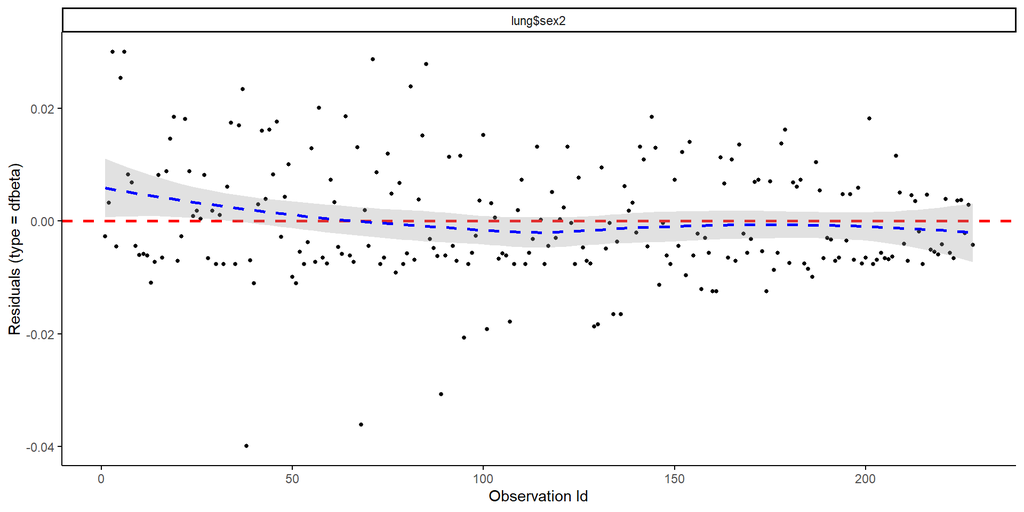

```r
ggcoxdiagnostics(coxrm_1, type = "dfbeta",
                 linear.predictions = FALSE, ggtheme = theme_classic())
```

There are no single values, that are very influential.

#### 2.3.1.2 Categorical Predictor Variable

We will now use the ECOG performance score (ph.ecog) as an ordinal predictor (using it as continuous would not make a lot of sense, since we cannot assume that the differences in effect scale over the different groups => e.g. difference between 0 and 2 is the same as between 1 and 3)

ECOG performance score as rated by the physician:  
- 0 = asymptomatic  
- 1 = symptomatic but completely ambulatory  
- 2 = in bed <50% of the day  
- 3 = in bed > 50% of the day but not bedbound  
- 4 = bedbound

How many patients per group participated in the study?

```r
table(lung$ph.ecog)
```

```
##
##   0   1   2   3
##  63 113  50   1
```

There are none in group 4 and only one in group 3. The total of the table is 227, meaning that one record is missing.

There is one record with an NA value for ph.ecog.

Produce a kaplan-meier plot for the different groups:

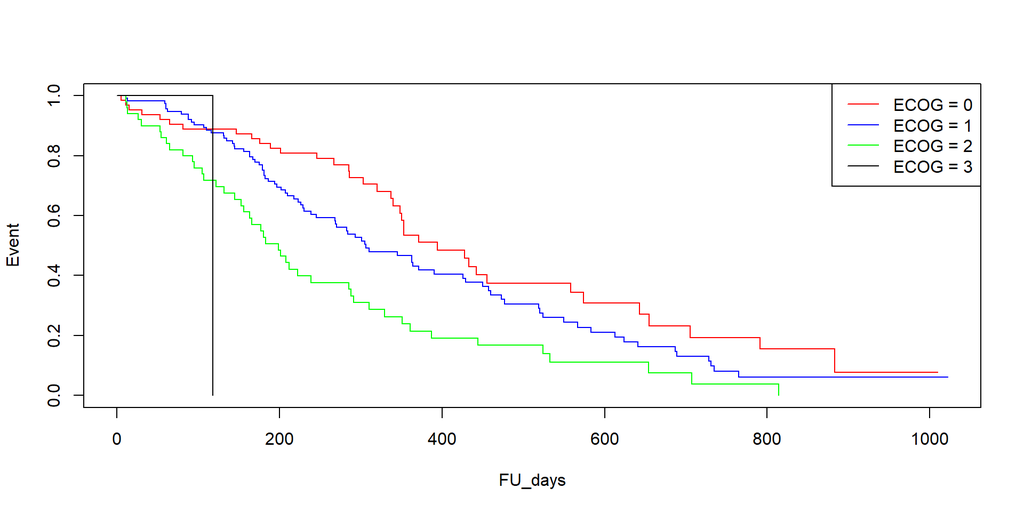

```r
plot(survfit(surv_lung ~ lung$ph.ecog), col = c("red", "blue", "green", "black"), xlab = "FU_days", ylab = "Event")
legend("topright", c("ECOG = 0", "ECOG = 1", "ECOG = 2", "ECOG = 3"), col = c("red", "blue", "green", "black"), lty = "solid")
```

We can see that generally the patients with higher scores die earlier in groups 0 to 2. For group 3 we cannot really make much of a statement since there was only one patient.

We will now fit models with or without the record for group 3 in order to see if it containing only one record leads to problems with the model.

In order to fit a model with ECOG score as ordinal we can produce dummy variables for the groups (since we had previously formated the variable as factor, it would also work without this step):

```r
lung_ecog_d <- lung %>%
  select(time, status, ph.ecog) %>%
  mutate(ph.ecog_0 = as.numeric(ph.ecog == 0),
         ph.ecog_1 = as.numeric(ph.ecog == 1),
         ph.ecog_2 = as.numeric(ph.ecog == 2),
         ph.ecog_3 = as.numeric(ph.ecog == 3))
```

```r
#filter out the NA value
lung_ecog_d_filt <- lung_ecog_d %>%
  filter(is.na(ph.ecog) == FALSE)

#create survival object
surv_ecog_d <-  Surv(lung_ecog_d_filt$time, lung_ecog_d_filt$status)

#fit model
coxrm_3 <- coxph(surv_ecog_d ~ lung_ecog_d_filt$ph.ecog_3 + lung_ecog_d_filt$ph.ecog_2 + lung_ecog_d_filt$ph.ecog_1 + lung_ecog_d_filt$ph.ecog_0)
summary(coxrm_3)
```

```
## Call:
## coxph(formula = surv_ecog_d ~ lung_ecog_d_filt$ph.ecog_3 + lung_ecog_d_filt$ph.ecog_2 +
##     lung_ecog_d_filt$ph.ecog_1 + lung_ecog_d_filt$ph.ecog_0)
##
##   n= 227, number of events= 164
##
##                              coef exp(coef) se(coef)     z Pr(>|z|)
## lung_ecog_d_filt$ph.ecog_3 2.2080    9.0973   1.0258 2.152   0.0314 *
## lung_ecog_d_filt$ph.ecog_2 0.9164    2.5002   0.2245 4.081 4.48e-05 ***
## lung_ecog_d_filt$ph.ecog_1 0.3688    1.4461   0.1987 1.857   0.0634 .
## lung_ecog_d_filt$ph.ecog_0     NA        NA   0.0000    NA       NA
## ---
## Signif. codes:  0 '***' 0.001 '**' 0.01 '*' 0.05 '.' 0.1 ' ' 1
##
##                            exp(coef) exp(-coef) lower .95 upper .95
## lung_ecog_d_filt$ph.ecog_3     9.097     0.1099    1.2182    67.937
## lung_ecog_d_filt$ph.ecog_2     2.500     0.4000    1.6101     3.883
## lung_ecog_d_filt$ph.ecog_1     1.446     0.6915    0.9797     2.134
## lung_ecog_d_filt$ph.ecog_0        NA         NA        NA        NA
##
## Concordance= 0.604  (se = 0.024 )
## Likelihood ratio test= 18.44  on 3 df,   p=4e-04
## Wald test            = 20.22  on 3 df,   p=2e-04
## Score (logrank) test = 21.97  on 3 df,   p=7e-05
```

The differences with ECOG = 0 are significant for the groups 2 and 3 and close to it for group 1 (p = 0.0634).  
For group 3 there is a very big confidence interval, which makes sense, as we only have one record in it. Therefore the estimated coefficient for this group is not very useful.

Fit a model without the record from group 3:

```r
#filter out the record from group 3
lung_ecog_d_filt_wo3 <- lung_ecog_d_filt %>% filter(ph.ecog_3 != 1)
#create survival object
surv_ecog_wo3 <- Surv(lung_ecog_d_filt_wo3$time, lung_ecog_d_filt_wo3$status)
#fit model
coxrm_4 <- coxph(surv_ecog_wo3 ~ lung_ecog_d_filt_wo3$ph.ecog_2 + lung_ecog_d_filt_wo3$ph.ecog_1 + lung_ecog_d_filt_wo3$ph.ecog_0)
summary(coxrm_4)
```

```
## Call:
## coxph(formula = surv_ecog_wo3 ~ lung_ecog_d_filt_wo3$ph.ecog_2 +
##     lung_ecog_d_filt_wo3$ph.ecog_1 + lung_ecog_d_filt_wo3$ph.ecog_0)
##
##   n= 226, number of events= 163
##
##                                  coef exp(coef) se(coef)     z Pr(>|z|)
## lung_ecog_d_filt_wo3$ph.ecog_2 0.9153    2.4975   0.2246 4.076 4.58e-05 ***
## lung_ecog_d_filt_wo3$ph.ecog_1 0.3686    1.4458   0.1987 1.856   0.0635 .
## lung_ecog_d_filt_wo3$ph.ecog_0     NA        NA   0.0000    NA       NA
## ---
## Signif. codes:  0 '***' 0.001 '**' 0.01 '*' 0.05 '.' 0.1 ' ' 1
##
##                                exp(coef) exp(-coef) lower .95 upper .95
## lung_ecog_d_filt_wo3$ph.ecog_2     2.498     0.4004    1.6083     3.878
## lung_ecog_d_filt_wo3$ph.ecog_1     1.446     0.6917    0.9795     2.134
## lung_ecog_d_filt_wo3$ph.ecog_0        NA         NA        NA        NA
##
## Concordance= 0.602  (se = 0.024 )
## Likelihood ratio test= 16.53  on 2 df,   p=3e-04
## Wald test            = 17.28  on 2 df,   p=2e-04
## Score (logrank) test = 18.04  on 2 df,   p=1e-04
```

This only led to minor changes in the model.  
So including the record from group 3 seems not to lead to any problems, but it probably does not make much sense to give to much weight to the calculated coefficient, as the sample size for this group is way too small.

**Test Model Assumptions**

- Proportional Hazards Assumption

Test both of the models we have fit: Including group 3

```r
coxrm_3_ph <- cox.zph(coxrm_3)
coxrm_3_ph
```

```
##                            chisq df     p
## lung_ecog_d_filt$ph.ecog_3 2.779  1 0.096
## lung_ecog_d_filt$ph.ecog_2 2.033  1 0.154
## lung_ecog_d_filt$ph.ecog_1 0.287  1 0.592
## GLOBAL                     4.876  3 0.181
```

Without group 3

```r
coxrm_4_ph <- cox.zph(coxrm_4)
coxrm_4_ph
```

```
##                                chisq df    p
## lung_ecog_d_filt_wo3$ph.ecog_2 1.960  1 0.16
## lung_ecog_d_filt_wo3$ph.ecog_1 0.301  1 0.58
## GLOBAL                         2.092  2 0.35
```

The p value of the global test changed, but the assumption is fulfilled for both models.

- Testing Influential Observations

Including group 3

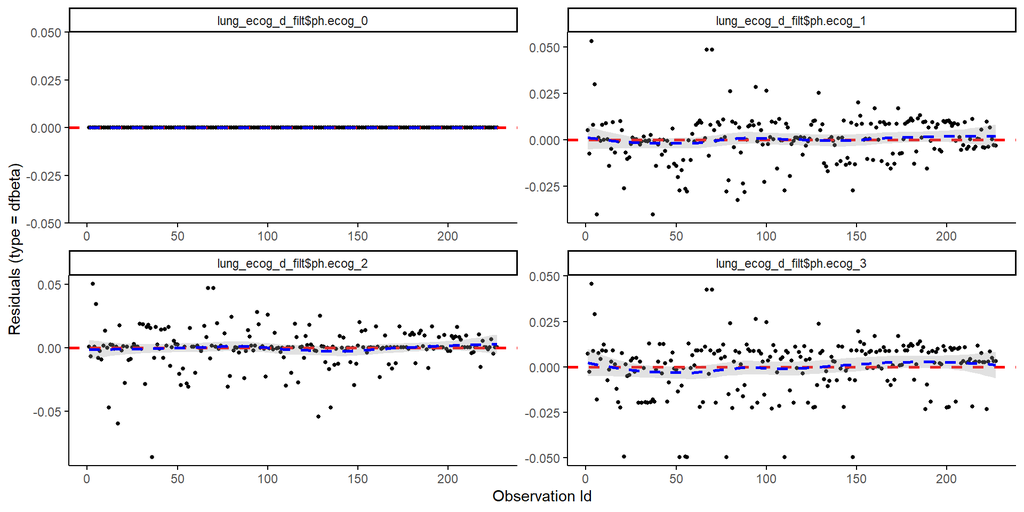

```r
ggcoxdiagnostics(coxrm_3, type = "dfbeta",
                 linear.predictions = FALSE, ggtheme = theme_classic())
```

Without group 3

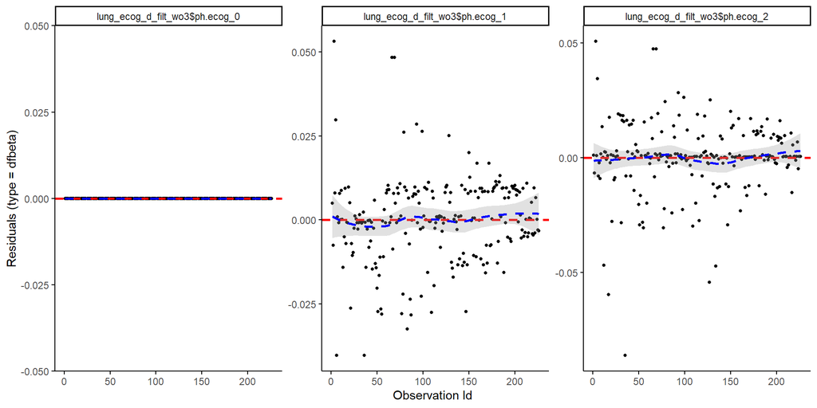

```r
ggcoxdiagnostics(coxrm_4, type = "dfbeta",
                 linear.predictions = FALSE, ggtheme = theme_classic())
```

The reference category cannot really be inspected. I dont know why this is the case. For the other groups there seem not to be any too influential observations.

#### 2.3.1.3 Continuous Predictor Variable

We will use the age of the patients as predictor.

Look at age distribution in the sample:

```r
summary(lung$age)
```

```
##    Min. 1st Qu.  Median    Mean 3rd Qu.    Max.
##   39.00   56.00   63.00   62.45   69.00   82.00
```

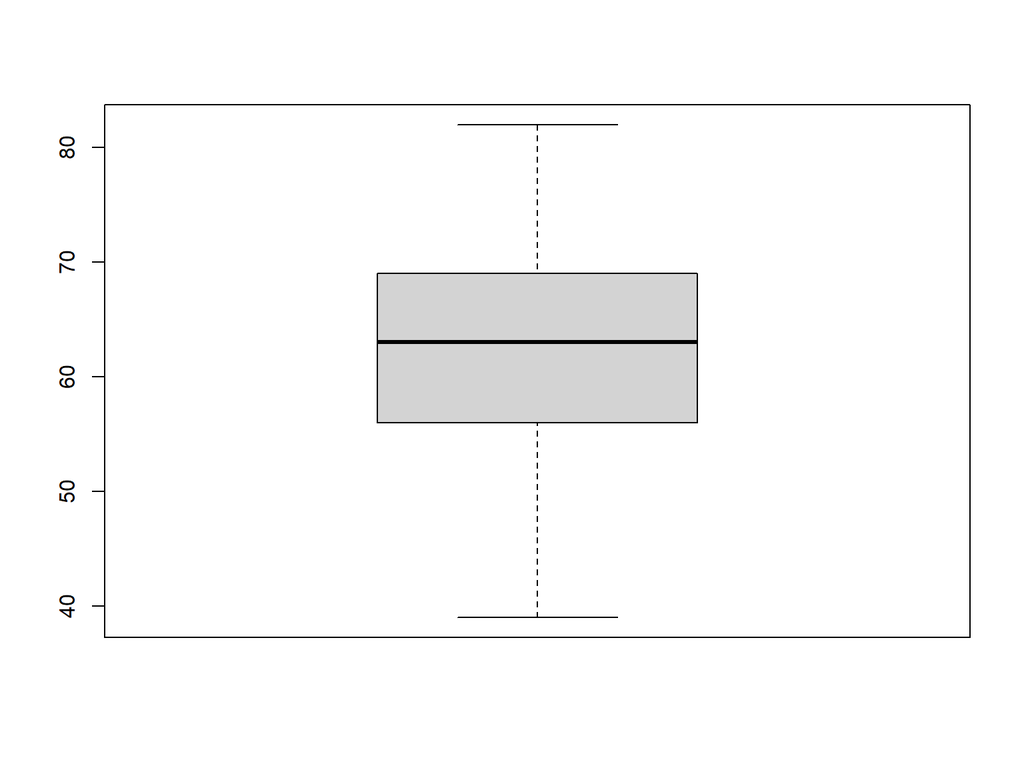

```r
boxplot(lung$age)
```

The distribution is quite symmetric with a range from 39 to 82 and a mean of around 63.

Fit the model:

```r
coxrm_5 <- coxph(surv_lung ~ lung$age)
summary(coxrm_5)
```

```
## Call:
## coxph(formula = surv_lung ~ lung$age)
##
##   n= 228, number of events= 165
##
##              coef exp(coef) se(coef)     z Pr(>|z|)
## lung$age 0.018720  1.018897 0.009199 2.035   0.0419 *
## ---
## Signif. codes:  0 '***' 0.001 '**' 0.01 '*' 0.05 '.' 0.1 ' ' 1
##
##          exp(coef) exp(-coef) lower .95 upper .95
## lung$age     1.019     0.9815     1.001     1.037
##
## Concordance= 0.55  (se = 0.025 )
## Likelihood ratio test= 4.24  on 1 df,   p=0.04
## Wald test            = 4.14  on 1 df,   p=0.04
## Score (logrank) test = 4.15  on 1 df,   p=0.04
```

There is a significant association between age and survival time. However it is not very clear (the confidence interval for the hazard ratio is close to 1 and the p value 0.0419, close to 0.05).

**Test Model Assumptions**

- Proportional Hazards Assumption

```r
coxrm_5_ph <- cox.zph(coxrm_5)
coxrm_5_ph
```

```
##          chisq df    p
## lung$age 0.346  1 0.56
## GLOBAL   0.346  1 0.56
```

The proportional hazards assumption is fulfilled for this model.

- Testing Influential Observations

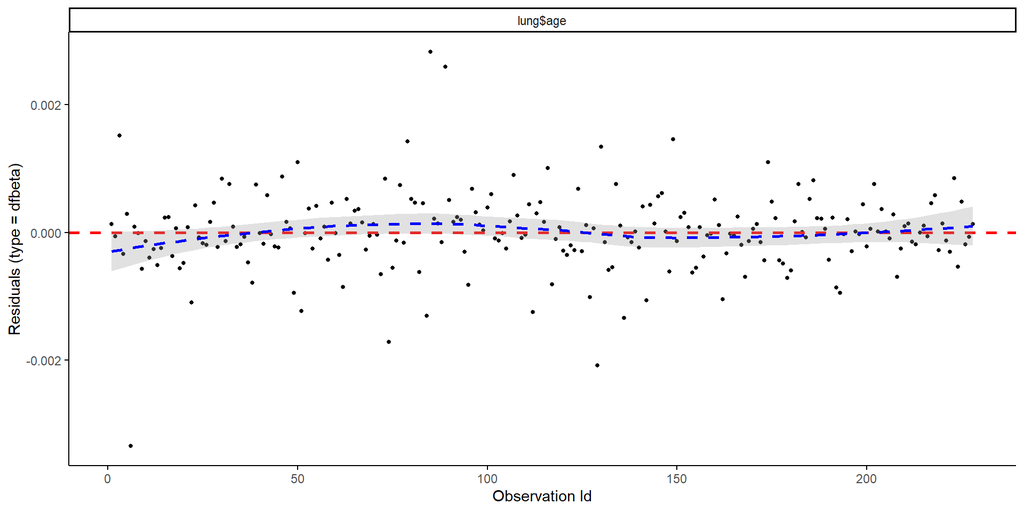

```r
ggcoxdiagnostics(coxrm_5, type = "dfbeta",
                 linear.predictions = FALSE, ggtheme = theme_classic())
```

None of the observations seem to be too influential.

- Non Linearity

Since we now use a continuous predictor we also have to test if this predictor and the outcome (log of hazard) have a linear relationship.  
One way to test this, is by binning the predictor variable (for example by quartiles) and then fitting a model of these bins as ordinal variable and check if the coefficients increase or decrease in a more or less linear fashion, meaning the most extreme values in one direction show the biggest difference from the most extreme values in the other direction.

Get borders of quartiles:

```r
quart_age <- quantile(lung$age, prob=c(0,.25,.5,.75,1))
```

Bin the data

```r
lung_age_bin <- lung %>%
  mutate(age_1q = as.numeric(between(age, quart_age[1], quart_age[2])),
         age_2q = as.numeric(between(age, quart_age[2], quart_age[3])),
         age_3q = as.numeric(between(age, quart_age[3], quart_age[4])),
         age_4q = as.numeric(between(age, quart_age[4], quart_age[5])))
```

Fit a model

```r
coxrm_6 <- coxph(surv_lung ~ lung_age_bin$age_1q + lung_age_bin$age_2q + lung_age_bin$age_3q + lung_age_bin$age_4q)
summary(coxrm_6)
```

```
## Call:
## coxph(formula = surv_lung ~ lung_age_bin$age_1q + lung_age_bin$age_2q +
##     lung_age_bin$age_3q + lung_age_bin$age_4q)
##
##   n= 228, number of events= 165
##
##                          coef exp(coef)  se(coef)      z Pr(>|z|)
## lung_age_bin$age_1q -0.333968  0.716077  0.299087 -1.117    0.264
## lung_age_bin$age_2q -0.235591  0.790104  0.266154 -0.885    0.376
## lung_age_bin$age_3q -0.310735  0.732908  0.256069 -1.213    0.225
## lung_age_bin$age_4q  0.007027  1.007052  0.291288  0.024    0.981
##
##                     exp(coef) exp(-coef) lower .95 upper .95
## lung_age_bin$age_1q    0.7161      1.396    0.3985     1.287
## lung_age_bin$age_2q    0.7901      1.266    0.4690     1.331
## lung_age_bin$age_3q    0.7329      1.364    0.4437     1.211
## lung_age_bin$age_4q    1.0071      0.993    0.5690     1.782
##
## Concordance= 0.542  (se = 0.024 )
## Likelihood ratio test= 4.5  on 4 df,   p=0.3
## Wald test            = 4.54  on 4 df,   p=0.3
## Score (logrank) test = 4.57  on 4 df,   p=0.3
```

We see that the coefficients dont increase in a linear fashion. The biggest difference is between the fourth quartile and the other three. There seems to be no clear trend for Quartiles 1 to 3. It looks like young age (in quart 1-3) might have some protective effect.

The assumption of linearity is therefore not fulfilled.

Alternatively we can use the survminer::ggcoxfunctional function

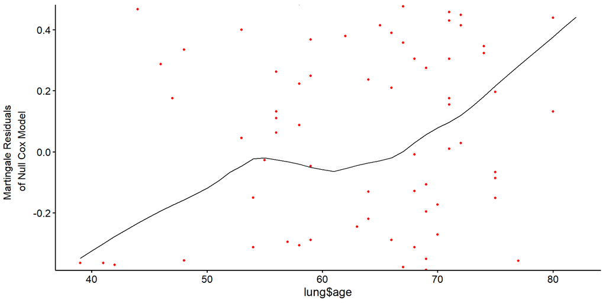

```r
ggcoxfunctional(coxrm_5, data = lung)
```

The fitted line should be linear to in order to fulfill the linearity assumption. Here also this is not fulfilled.

### 2.3.2 Multiple Cox Regression

#### 2.3.2.1 Binary + Categorical Predictor Variables

We will use sex and ECOG rating as predictors for survival.

Produce Kaplan-Meier plot for each combination of ECOG rating and sex:

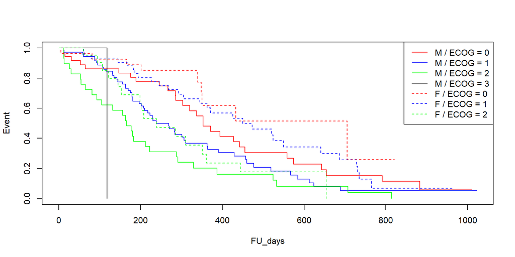

```r
plot(survfit(surv_lung ~ lung$sex + lung$ph.ecog),
     col = c("red", "blue", "green", "black", "red", "blue", "green"),
     lty=c(1, 1, 1, 1, 2, 2, 2),
     xlab = "FU_days", ylab = "Event")
legend("topright", c("M / ECOG = 0", "M / ECOG = 1", "M / ECOG = 2", "M / ECOG = 3",
                     "F / ECOG = 0", "F / ECOG = 1", "F / ECOG = 2"),
       col = c("red", "blue", "green", "black", "red", "blue", "green"),
       lty=c(1, 1, 1, 1, 2, 2, 2))
```

When we compare the female to male curves with the same ECOG ratings we see that survival times are generally higher for women. When we compare the ECOG ratings for people of the same sex, we can see the same tendency as observed above, that a higher ECOG rating generally indicates lower survival times.

From this we can say that there is confounding between the variables and we can expect a model that includes both of these to be better then the models using only one of them.

Fit model:

```r
mcoxrm_1 <- coxph(surv_lung ~ lung$sex + lung$ph.ecog)
summary(mcoxrm_1)
```

```
## Call:
## coxph(formula = surv_lung ~ lung$sex + lung$ph.ecog)
##
##   n= 227, number of events= 164
##    (1 observation deleted due to missingness)
##
##                  coef exp(coef) se(coef)      z Pr(>|z|)
## lung$sex2     -0.5449    0.5799   0.1681 -3.241  0.00119 **
## lung$ph.ecog1  0.4182    1.5192   0.1994  2.097  0.03602 *
## lung$ph.ecog2  0.9475    2.5792   0.2248  4.216 2.49e-05 ***
## lung$ph.ecog3  2.0485    7.7565   1.0269  1.995  0.04605 *
## ---
## Signif. codes:  0 '***' 0.001 '**' 0.01 '*' 0.05 '.' 0.1 ' ' 1
##
##               exp(coef) exp(-coef) lower .95 upper .95
## lung$sex2        0.5799     1.7245    0.4171    0.8062
## lung$ph.ecog1    1.5192     0.6582    1.0277    2.2459
## lung$ph.ecog2    2.5792     0.3877    1.6602    4.0067
## lung$ph.ecog3    7.7565     0.1289    1.0366   58.0390
##
## Concordance= 0.642  (se = 0.025 )
## Likelihood ratio test= 29.5  on 4 df,   p=6e-06
## Wald test            = 30.7  on 4 df,   p=4e-06
## Score (logrank) test = 32.71  on 4 df,   p=1e-06
```

Both variables are significantly different from zero at an alpha of 0.05. Even all the levels of the ECOG ranking are significant, as we can see from the respective p-values being lower then 0.05 and the 95% CIs that exclude 1.

We can see that the general tendencies we have observed in the Kaplan-Meier plot are represented here in the model. Meaning women having lower risk (sex = 2 has an exp(coefficient) lower then one) and higher ECOG ranking has higher risk, represented by the exp of the coefficients increasing with higher rankings.

The concordance can be used to evaluate how well the model fits the data. Larger values are better.  
Set up a data frame with all the values of the models fit so far

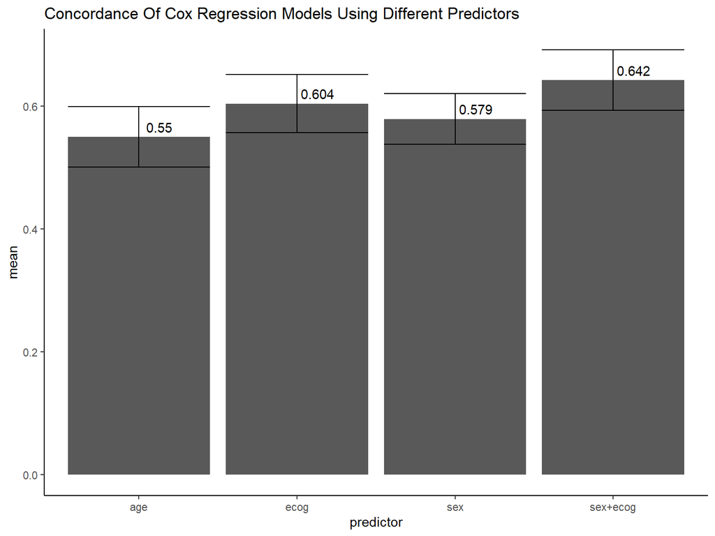

```r
conc_coxm <- data.frame(mean = c(0.579, 0.604, 0.55, 0.642),
                        se = c(0.021, 0.024, 0.025, 0.025),
                        predictor = c("sex", "ecog", "age", "sex+ecog"))
#calculate 95% CIs
conc_coxm <- conc_coxm %>% mutate(lci = mean-qt(p=0.975, df = 227)*se,
                                  uci = mean+qt(p=0.975, df = 227)*se)
#plot
conc_coxm %>% ggplot(aes(y = mean, x = predictor)) +
  geom_bar(stat="identity") +
  geom_errorbar(aes(ymin = lci, ymax = uci)) +
  theme_classic() +
  geom_text(aes(label = mean), nudge_y = 0.016, nudge_x = 0.13) +
  labs(title = "Concordance Of Cox Regression Models Using Different Predictors")
```

We can see that the value for the model using sex and the ECOG score has a higher concordance value then the previous models using only one predictor variable. So the combination of the two predictors seems to improve the model as was speculated above.  
Of the previous models the one with the ECOG ranking was the best.

Lets find out if there was statistically significant confounding by looking at changes in the coefficients of the model:

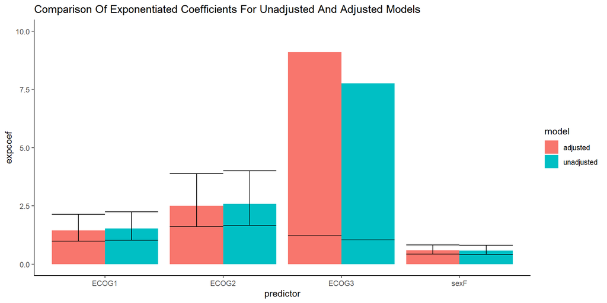

```r
coeff_unadj_adj <- data.frame(expcoef = c(0.5799, 1.5192, 2.5792, 7.7565, 0.588, 1.446, 2.500, 9.097),
                           lci = c(0.4171, 1.0277, 1.6602, 1.0366, 0.4237, 0.9797, 1.6101, 1.2182),
                           uci = c(0.8062, 2.2459, 4.0067, 58.0390, 0.816, 2.134, 3.883, 67.937),
                           predictor = c("sexF", "ECOG1", "ECOG2", "ECOG3", "sexF", "ECOG1", "ECOG2", "ECOG3"),
                           model = c("unadjusted", "unadjusted", "unadjusted", "unadjusted", "adjusted", "adjusted", "adjusted", "adjusted"))

#coeff_c_vs_s
coeff_unadj_adj %>% ggplot(aes(x = predictor, y = expcoef, fill = model)) +
  geom_bar(position = "dodge", stat = "identity") +
  geom_errorbar(aes(ymin = lci, ymax = uci), position=position_dodge(.9)) +
  ylim(0, 10) +
  theme_classic() +
  labs(title = "Comparison Of Exponentiated Coefficients For Unadjusted And Adjusted Models")
```

The changes in the coefficients are not statistically significant for any of them. I am not sure why.

**Test Model Assumptions**

- Proportional Hazards Assumption

We have already previously tested this for sex and ECOG rating.

- Testing Influential Observations

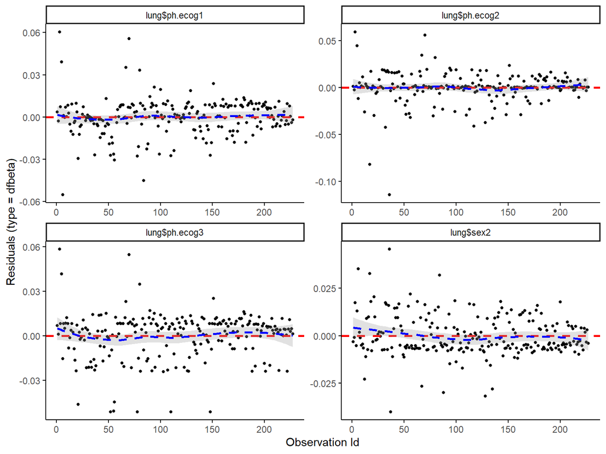

```r
ggcoxdiagnostics(mcoxrm_1, type = "dfbeta",
                 linear.predictions = FALSE, ggtheme = theme_classic())
```

None of the observations seem to be too influential.

#### 2.3.2.2 Binary + Categorical + Continuous Predictor Variables

We will now also add Age as a predictor variable:

lets look at the age distributions for sex, ECOG groups and their combinations:

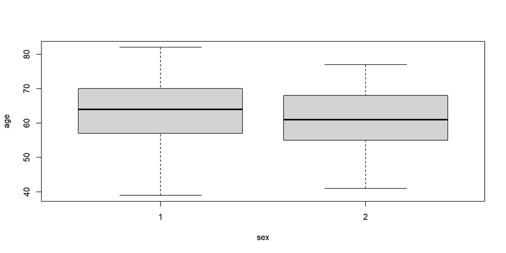

```r
boxplot(data = lung, age ~ sex)
```

We see that in general the women in the sample are a bit younger.

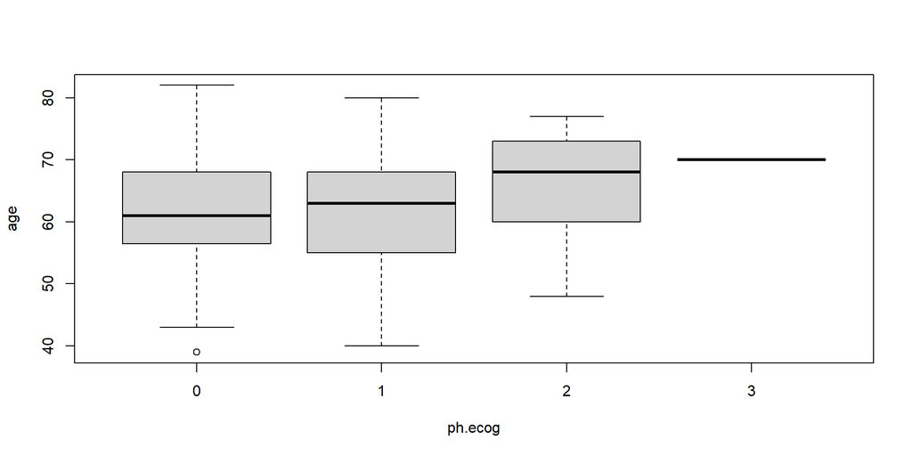

```r
boxplot(data = lung, age ~ ph.ecog)
```

We see that the the patients with higher ecog scores are generally older than the ones with lower scores. This makes sense if we assume that the onset for the disease is around the same age for most people. We can expect the disease to progress over time leading to more severe symptoms and therefore higher ECOG rankings at higher age.

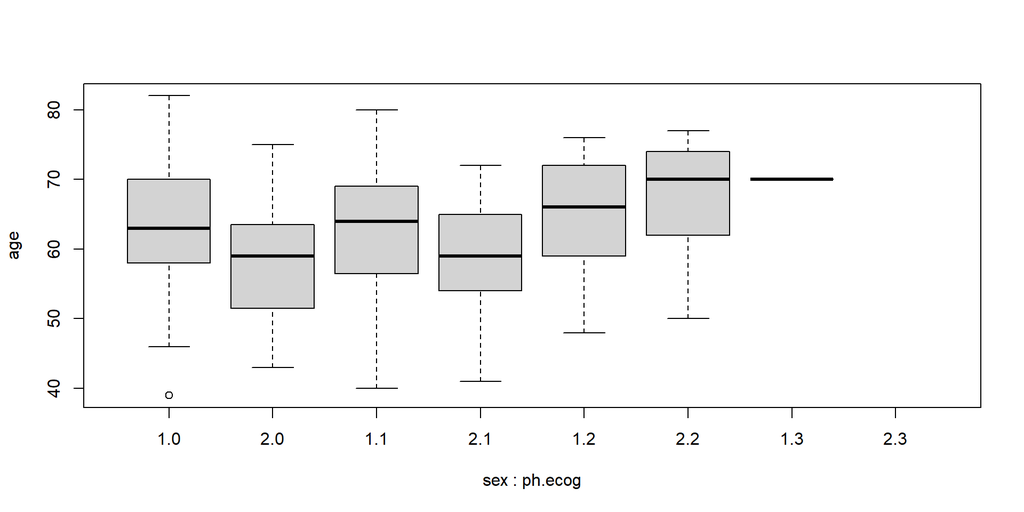

```r
boxplot(data = lung, age ~ sex + ph.ecog)
```

Fit a model:

```r
mcoxrm_2 <- coxph(surv_lung ~ lung$sex + lung$ph.ecog + lung$age)
summary(mcoxrm_2)
```

```
## Call:
## coxph(formula = surv_lung ~ lung$sex + lung$ph.ecog + lung$age)
##
##   n= 227, number of events= 164
##    (1 observation deleted due to missingness)
##
##                    coef exp(coef)  se(coef)      z Pr(>|z|)
## lung$sex2     -0.545831  0.579360  0.168228 -3.245  0.00118 **
## lung$ph.ecog1  0.410048  1.506890  0.199604  2.054  0.03995 *
## lung$ph.ecog2  0.903303  2.467741  0.228078  3.960 7.48e-05 ***
## lung$ph.ecog3  1.954543  7.060694  1.029701  1.898  0.05767 .
## lung$age       0.010795  1.010853  0.009312  1.159  0.24637
## ---
## Signif. codes:  0 '***' 0.001 '**' 0.01 '*' 0.05 '.' 0.1 ' ' 1
##
##               exp(coef) exp(-coef) lower .95 upper .95
## lung$sex2        0.5794     1.7260    0.4166    0.8056
## lung$ph.ecog1    1.5069     0.6636    1.0190    2.2284
## lung$ph.ecog2    2.4677     0.4052    1.5782    3.8587
## lung$ph.ecog3    7.0607     0.1416    0.9383   53.1289
## lung$age         1.0109     0.9893    0.9926    1.0295
##
## Concordance= 0.637  (se = 0.025 )
## Likelihood ratio test= 30.87  on 5 df,   p=1e-05
## Wald test            = 31.43  on 5 df,   p=8e-06
## Score (logrank) test = 33.56  on 5 df,   p=3e-06
```

We see that the coefficient fit for age does not differ significantly from zero at an alpha of 0.05. We can try to look at this in the light of the previously fit models and produced plots. The model fit with only age as predictor gave a hazard ratio for only a little more then one for every increase of 1 year in age. The p-value was only slightly below the alpha. The unadjusted model we had fit for sex gave a risk ratio <1 which was more clearly found to be significant. For ECOG ranking the risk increased with higher rankings and the risk ratios where more clearly found to be significantly different from 1.  
In the graph above we saw that in ECOG = 2 women are generally older then man. This means that the general tendencies of the influence of age and sex on the survival are not the same in all groups of ECOG ranking. This might be the reason for the coefficient for age not being significantly different from zero.

Concordance of this model is slightly lower then for the model fit with sex and ECOG ranking only.

### 2.3.3 Finding The Best Model

Since in this data set we have several more variables, we can now try to find the combination of variables, which gives us the “best” model.

We will do this via backwards selection. This means we will fit a model including all variables and then remove variables from the model to improve it. We will not do this by a fix criterium (such as always remove the variable with the highest p-value), but will try to also consider other factors.

We will first do some reformatting

```r
lung <- survival::lung

#give more descriptive values for sex
lung$sex <- as.character(lung$sex )
lung <- lung %>% mutate(sex = replace(.$sex, sex == "1", "male")) %>%
        mutate(sex = replace(.$sex, sex == "2", "female"))

#convert factors to factors:
lung$inst <- as.factor(lung$inst)
lung$sex <- as.factor(lung$sex)
lung$ph.ecog <- as.factor(lung$ph.ecog)

str(lung)
```

```
## 'data.frame':    228 obs. of  10 variables:
##  $ inst     : Factor w/ 18 levels "1","2","3","4",..: 3 3 3 5 1 10 7 9 1 7 ...
##  $ time     : num  306 455 1010 210 883 ...
##  $ status   : num  2 2 1 2 2 1 2 2 2 2 ...
##  $ age      : num  74 68 56 57 60 74 68 71 53 61 ...
##  $ sex      : Factor w/ 2 levels "female","male": 2 2 2 2 2 2 1 1 2 2 ...
##  $ ph.ecog  : Factor w/ 4 levels "0","1","2","3": 2 1 1 2 1 2 3 3 2 3 ...
##  $ ph.karno : num  90 90 90 90 100 50 70 60 70 70 ...
##  $ pat.karno: num  100 90 90 60 90 80 60 80 80 70 ...
##  $ meal.cal : num  1175 1225 NA 1150 NA ...
##  $ wt.loss  : num  NA 15 15 11 0 0 10 1 16 34 ...
```

Lets see how many NAs there are per row:

```r
lung %>% is.na() %>% colSums()
```

```
##      inst      time    status       age       sex   ph.ecog  ph.karno pat.karno
##         1         0         0         0         0         1         1         3
##  meal.cal   wt.loss
##        47        14
```

How many records are complete?

```r
lung %>% complete.cases() %>% table()
```

```
## .
## FALSE  TRUE
##    61   167
```

Its not too many. Lets fit a model using all the variables and ignoring the records with NAs:

```r
mcoxrm_all <- coxph(data = lung, Surv(time = lung$time, event = lung$status) ~ .)
summary(mcoxrm_all)
```

```
## Call:
## coxph(formula = Surv(time = lung$time, event = lung$status) ~
##     ., data = lung)
##
##   n= 167, number of events= 120
##    (61 observations deleted due to missingness)
##
##                 coef  exp(coef)   se(coef)      z Pr(>|z|)
## inst2      0.5583356  1.7477610  0.6462712  0.864 0.387624
## inst3     -0.2494338  0.7792418  0.4168714 -0.598 0.549608
## inst4     -0.9341026  0.3929383  0.5783879 -1.615 0.106308
## inst5      0.0241322  1.0244257  0.5119380  0.047 0.962403
## inst6      0.0553193  1.0568780  0.4060917  0.136 0.891644
## inst7     -0.3160873  0.7289958  0.5252902 -0.602 0.547348
## inst10     0.8882025  2.4307564  0.5728797  1.550 0.121041
## inst11    -0.6528069  0.5205825  0.4431986 -1.473 0.140766
## inst12     0.1330591  1.1423175  0.3972728  0.335 0.737677
## inst13    -0.8155267  0.4424063  0.4736663 -1.722 0.085118 .
## inst15    -0.2010022  0.8179106  0.5783189 -0.348 0.728168
## inst16    -1.2567943  0.2845648  0.4797496 -2.620 0.008801 **
## inst21     0.0714592  1.0740743  0.4584310  0.156 0.876129
## inst22    -1.1514853  0.3161668  0.4226901 -2.724 0.006446 **
## inst26    -0.5624859  0.5697909  0.7561537 -0.744 0.456950
## inst32    -0.3021406  0.7392341  0.7674009 -0.394 0.693788
## inst33            NA         NA  0.0000000     NA       NA
## age        0.0028243  1.0028283  0.0127815  0.221 0.825118
## sexmale    0.7408981  2.0978187  0.2153653  3.440 0.000581 ***
## ph.ecog1   0.6365211  1.8898947  0.3007201  2.117 0.034289 *
## ph.ecog2   1.9879392  7.3004735  0.5253382  3.784 0.000154 ***
## ph.ecog3   3.6784141 39.5835687  1.2112283  3.037 0.002390 **
## ph.karno   0.0262162  1.0265628  0.0124887  2.099 0.035800 *
## pat.karno -0.0101041  0.9899468  0.0094017 -1.075 0.282505
## meal.cal  -0.0001686  0.9998314  0.0002767 -0.609 0.542245
## wt.loss   -0.0181322  0.9820312  0.0084586 -2.144 0.032062 *
## ---
## Signif. codes:  0 '***' 0.001 '**' 0.01 '*' 0.05 '.' 0.1 ' ' 1
##
##           exp(coef) exp(-coef) lower .95 upper .95
## inst2        1.7478    0.57216    0.4925    6.2028
## inst3        0.7792    1.28330    0.3442    1.7641
```

[output cut: 14 more lines]

```
## inst33           NA         NA        NA        NA
## age          1.0028    0.99718    0.9780    1.0283
## sexmale      2.0978    0.47669    1.3755    3.1995
## ph.ecog1     1.8899    0.52913    1.0482    3.4073
## ph.ecog2     7.3005    0.13698    2.6072   20.4418
## ph.ecog3    39.5836    0.02526    3.6857  425.1227
## ph.karno     1.0266    0.97412    1.0017    1.0520
## pat.karno    0.9899    1.01016    0.9719    1.0084
## meal.cal     0.9998    1.00017    0.9993    1.0004
## wt.loss      0.9820    1.01830    0.9659    0.9984
##
## Concordance= 0.697  (se = 0.029 )
## Likelihood ratio test= 54.28  on 25 df,   p=6e-04
## Wald test            = 55.29  on 25 df,   p=5e-04
## Score (logrank) test = 59.47  on 25 df,   p=1e-04
```

It seems unlikely that the institution variable adds much to the model. While it might be plausible that the survival could be better in some institutions, due to varying treatment quality, it seems unlikely that a clear difference between all of the 18 institutions in this data set.

Lets perform a partial F test to see if the difference between the models with and without the institution variable as a predictor is significant.

In order to do this, we have to refit the model including all variables without the record, where inst == NA:

```r
lung_2 <- lung %>% filter(!is.na(.$inst))

mcoxrm_all_2 <- coxph(data = lung_2, Surv(time = lung_2$time, event = lung_2$status) ~ .)
```

Produce a data frame without inst:

```r
lung_sel3 <- lung_2 %>% select(!inst)
```

Fit the model without inst and run an anova comparing them:

```r
mcoxrm_3 <- coxph(data = lung_sel3, Surv(time = lung_2$time, event = lung_2$status) ~ .)
anova(mcoxrm_all_2, mcoxrm_3)
```

```
## Analysis of Deviance Table
##  Cox model: response is  Surv(time = lung_2$time, event = lung_2$status)
##  Model 1: ~ inst + age + sex + ph.ecog + ph.karno + pat.karno + meal.cal + wt.loss
##  Model 2: ~ age + sex + ph.ecog + ph.karno + pat.karno + meal.cal + wt.loss
##    loglik  Chisq Df P(>|Chi|)
## 1 -480.98
## 2 -493.80 25.653 16   0.05911 .
## ---
## Signif. codes:  0 '***' 0.001 '**' 0.01 '*' 0.05 '.' 0.1 ' ' 1
```

The difference between the models is not significant. We can therefore omit the institution variable from the model.

Present the model without inst:

```r
summary(mcoxrm_3)
```

```
## Call:
## coxph(formula = Surv(time = lung_2$time, event = lung_2$status) ~
##     ., data = lung_sel3)
##
##   n= 167, number of events= 120
##    (60 observations deleted due to missingness)
##
##                 coef  exp(coef)   se(coef)      z Pr(>|z|)
## age        9.979e-03  1.010e+00  1.173e-02  0.851  0.39503
## sexmale    5.489e-01  1.731e+00  2.023e-01  2.713  0.00667 **
## ph.ecog1   6.470e-01  1.910e+00  2.822e-01  2.293  0.02187 *
## ph.ecog2   1.454e+00  4.282e+00  4.621e-01  3.147  0.00165 **
## ph.ecog3   2.762e+00  1.584e+01  1.123e+00  2.460  0.01389 *
## ph.karno   2.207e-02  1.022e+00  1.132e-02  1.949  0.05128 .
## pat.karno -1.150e-02  9.886e-01  8.579e-03 -1.340  0.18013
## meal.cal   2.752e-05  1.000e+00  2.609e-04  0.105  0.91601
## wt.loss   -1.436e-02  9.857e-01  7.835e-03 -1.833  0.06681 .
## ---
## Signif. codes:  0 '***' 0.001 '**' 0.01 '*' 0.05 '.' 0.1 ' ' 1
##
##           exp(coef) exp(-coef) lower .95 upper .95
## age          1.0100    0.99007    0.9871     1.034
## sexmale      1.7314    0.57758    1.1646     2.574
## ph.ecog1     1.9098    0.52363    1.0984     3.320
## ph.ecog2     4.2815    0.23356    1.7310    10.590
## ph.ecog3    15.8356    0.06315    1.7535   143.007
## ph.karno     1.0223    0.97817    0.9999     1.045
## pat.karno    0.9886    1.01156    0.9721     1.005
## meal.cal     1.0000    0.99997    0.9995     1.001
## wt.loss      0.9857    1.01447    0.9707     1.001
##
## Concordance= 0.654  (se = 0.029 )
## Likelihood ratio test= 28.63  on 9 df,   p=7e-04
## Wald test            = 28.96  on 9 df,   p=7e-04
## Score (logrank) test = 31.06  on 9 df,   p=3e-04
```

Lets look at anova for this model, which “gives a sequential analysis of deviance table for that fit. That is, the reductions in the model Cox log-partial-likelihood as each term of the formula is added in turn are given in as the rows of a table, plus the log-likelihoods themselves” (Documentation of survival::anova.coxph):

```r
anova(mcoxrm_3)
```

```
## Analysis of Deviance Table
##  Cox model: response is Surv(time = lung_2$time, event = lung_2$status)
## Terms added sequentially (first to last)
##
##            loglik   Chisq Df Pr(>|Chi|)
## NULL      -508.12
## age       -506.36  3.5236  1   0.060503 .
## sex       -503.68  5.3571  1   0.020639 *
## ph.ecog   -497.72 11.9045  3   0.007718 **
## ph.karno  -496.05  3.3552  1   0.066992 .
## pat.karno -495.58  0.9365  1   0.333189
## meal.cal  -495.58  0.0012  1   0.972435
## wt.loss   -493.80  3.5520  1   0.059472 .
## ---
## Signif. codes:  0 '***' 0.001 '**' 0.01 '*' 0.05 '.' 0.1 ' ' 1
```

The variable meal.cal is not significant according to both the model summary and the deviance table. Since it also contains many NA values as seen above and has the highest p-value, it seems to be the best candidate to remove from the model in a next step.

Produce data frame without meal.cal:

```r
lung_4 <- lung %>% select(!inst & !meal.cal)
```

Fit a model:

```r
mcoxrm_4 <- coxph(data = lung_4, Surv(time = lung_4$time, event = lung_4$status) ~ .)
summary(mcoxrm_4)
```

```
## Call:
## coxph(formula = Surv(time = lung_4$time, event = lung_4$status) ~
##     ., data = lung_4)
##
##   n= 210, number of events= 148
##    (18 observations deleted due to missingness)
##
##                coef exp(coef)  se(coef)      z Pr(>|z|)
## age        0.013311  1.013400  0.009925  1.341 0.179877
## sexmale    0.619997  1.858922  0.179202  3.460 0.000541 ***
## ph.ecog1   0.718278  2.050899  0.251991  2.850 0.004366 **
## ph.ecog2   1.286642  3.620609  0.405633  3.172 0.001514 **
## ph.ecog3   2.719275 15.169327  1.099185  2.474 0.013365 *
## ph.karno   0.019794  1.019992  0.010146  1.951 0.051063 .
## pat.karno -0.016061  0.984067  0.007631 -2.105 0.035300 *
## wt.loss   -0.013250  0.986837  0.007008 -1.891 0.058673 .
## ---
## Signif. codes:  0 '***' 0.001 '**' 0.01 '*' 0.05 '.' 0.1 ' ' 1
##
##           exp(coef) exp(-coef) lower .95 upper .95
## age          1.0134    0.98678    0.9939    1.0333
## sexmale      1.8589    0.53795    1.3084    2.6412
## ph.ecog1     2.0509    0.48759    1.2516    3.3608
## ph.ecog2     3.6206    0.27620    1.6350    8.0178
## ph.ecog3    15.1693    0.06592    1.7593  130.7960
## ph.karno     1.0200    0.98040    0.9999    1.0405
## pat.karno    0.9841    1.01619    0.9695    0.9989
## wt.loss      0.9868    1.01334    0.9734    1.0005
##
## Concordance= 0.656  (se = 0.025 )
## Likelihood ratio test= 37.79  on 8 df,   p=8e-06
## Wald test            = 37.58  on 8 df,   p=9e-06
## Score (logrank) test = 40.26  on 8 df,   p=3e-06
```

The Concordance improved a little bit. Lets look at the deviance table for this model:

```r
anova(mcoxrm_4)
```

```
## Analysis of Deviance Table
##  Cox model: response is Surv(time = lung_4$time, event = lung_4$status)
## Terms added sequentially (first to last)
##
##            loglik   Chisq Df Pr(>|Chi|)
## NULL      -659.08
## age       -656.78  4.5896  1   0.032166 *
## sex       -652.32  8.9248  1   0.002813 **
## ph.ecog   -644.81 15.0231  3   0.001797 **
## ph.karno  -643.47  2.6722  1   0.102114
## pat.karno -642.06  2.8219  1   0.092985 .
## wt.loss   -640.18  3.7576  1   0.052567 .
## ---
## Signif. codes:  0 '***' 0.001 '**' 0.01 '*' 0.05 '.' 0.1 ' ' 1
```

One issue that might cause problems could be that the variables ph.karno and pat.karno might contain very similar information, since they both contain the “Karnofsky performance score”. The difference is only the assessor (patient vs. physician). One can assume, that they are at least somewhat correlated.

Lets produce a scatter plot to evaluate this. We add some noise in order to see all the records:

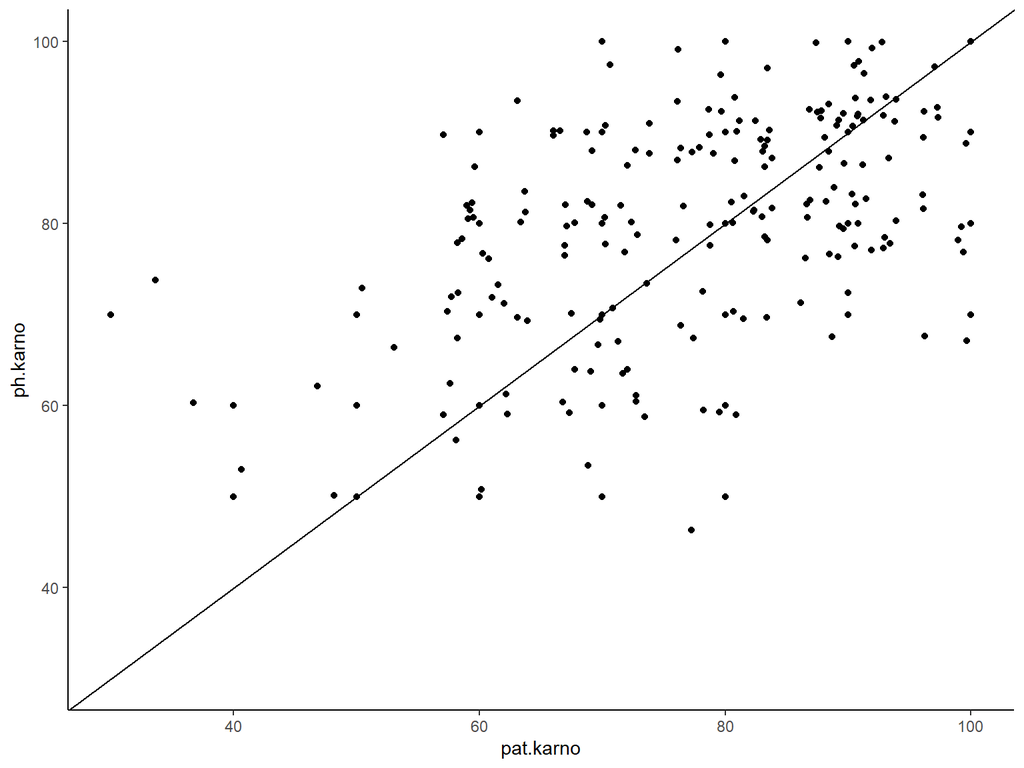

```r
lung %>% ggplot(aes(x = pat.karno, y = ph.karno)) +
        geom_point() +
        geom_jitter() +
        theme_classic() +
        xlim(30,100) +
        ylim(30,100) +
        geom_abline(slope = 1, intercept = 0)
```

The data seems more or less normally distributed around the y = x. So there seems to be some correlation here. Therefore the model would probably profit from removing one of these variables.

There are arguments for each of them. While the the physician has more routine in performing the assessment and can compare patients to each other, the patient “has more data” about how fit he/she is.

We will fit both models and compare them.

Produce data frame without pat.karno:

```r
lung_5 <- lung %>% select(!inst & !meal.cal & !pat.karno)
```

Fit a model:

```r
mcoxrm_5 <- coxph(data = lung_5, Surv(time = lung_5$time, event = lung_5$status) ~ .)
summary(mcoxrm_5)
```

```
## Call:
## coxph(formula = Surv(time = lung_5$time, event = lung_5$status) ~
##     ., data = lung_5)
##
##   n= 213, number of events= 151
##    (15 observations deleted due to missingness)
##
##               coef exp(coef)  se(coef)      z Pr(>|z|)
## age       0.014793  1.014903  0.009817  1.507 0.131842
## sexmale   0.622691  1.863938  0.177812  3.502 0.000462 ***
## ph.ecog1  0.673832  1.961741  0.248723  2.709 0.006745 **
## ph.ecog2  1.455396  4.286183  0.387220  3.759 0.000171 ***
## ph.ecog3  2.690274 14.735717  1.095118  2.457 0.014026 *
## ph.karno  0.015137  1.015252  0.009899  1.529 0.126225
## wt.loss  -0.009414  0.990630  0.006745 -1.396 0.162824
## ---
## Signif. codes:  0 '***' 0.001 '**' 0.01 '*' 0.05 '.' 0.1 ' ' 1
##
##          exp(coef) exp(-coef) lower .95 upper .95
## age         1.0149    0.98532    0.9956     1.035
## sexmale     1.8639    0.53650    1.3155     2.641
## ph.ecog1    1.9617    0.50975    1.2048     3.194
## ph.ecog2    4.2862    0.23331    2.0066     9.155
## ph.ecog3   14.7357    0.06786    1.7227   126.048
## ph.karno    1.0153    0.98498    0.9957     1.035
## wt.loss     0.9906    1.00946    0.9776     1.004
##
## Concordance= 0.64  (se = 0.026 )
## Likelihood ratio test= 33.86  on 7 df,   p=2e-05
## Wald test            = 33.77  on 7 df,   p=2e-05
## Score (logrank) test = 36.15  on 7 df,   p=7e-06
```

Produce data frame without ph.karno:

```r
lung_6 <- lung %>% select(!inst & !meal.cal & !ph.karno)
```

Fit a model:

```r
mcoxrm_6 <- coxph(data = lung_6, Surv(time = lung_5$time, event = lung_5$status) ~ .)
summary(mcoxrm_6)
```

```
## Call:
## coxph(formula = Surv(time = lung_5$time, event = lung_5$status) ~
##     ., data = lung_6)
##
##   n= 210, number of events= 148
##    (18 observations deleted due to missingness)
##
##                coef exp(coef)  se(coef)      z Pr(>|z|)
## age        0.010778  1.010836  0.009730  1.108  0.26797
## sexmale    0.572136  1.772047  0.177516  3.223  0.00127 **
## ph.ecog1   0.442710  1.556920  0.212079  2.087  0.03685 *
## ph.ecog2   0.753413  2.124238  0.298500  2.524  0.01160 *
## ph.ecog3   2.052020  7.783606  1.043131  1.967  0.04916 *
## pat.karno -0.013606  0.986486  0.007545 -1.803  0.07135 .
## wt.loss   -0.012098  0.987975  0.006907 -1.752  0.07985 .
## ---
## Signif. codes:  0 '***' 0.001 '**' 0.01 '*' 0.05 '.' 0.1 ' ' 1
##
##           exp(coef) exp(-coef) lower .95 upper .95
## age          1.0108     0.9893    0.9917     1.030
## sexmale      1.7720     0.5643    1.2513     2.509
## ph.ecog1     1.5569     0.6423    1.0274     2.359
## ph.ecog2     2.1242     0.4708    1.1834     3.813
## ph.ecog3     7.7836     0.1285    1.0075    60.131
## pat.karno    0.9865     1.0137    0.9720     1.001
## wt.loss      0.9880     1.0122    0.9747     1.001
##
## Concordance= 0.66  (se = 0.026 )
## Likelihood ratio test= 33.81  on 7 df,   p=2e-05
## Wald test            = 33.79  on 7 df,   p=2e-05
## Score (logrank) test = 36.43  on 7 df,   p=6e-06
```

The model with the assessment by the patient seems to be a bit better, since the Concordance is higher. We will therefore continue with this model. However I would not consider this strong evidence, that the patient assessment is a better predictor in general.

Lets look at the deviance table for this model:

```r
anova(mcoxrm_6)
```

```
## Analysis of Deviance Table
##  Cox model: response is Surv(time = lung_5$time, event = lung_5$status)
## Terms added sequentially (first to last)
##
##            loglik   Chisq Df Pr(>|Chi|)
## NULL      -659.08
## age       -656.78  4.5896  1   0.032166 *
## sex       -652.32  8.9248  1   0.002813 **
## ph.ecog   -644.81 15.0231  3   0.001797 **
## pat.karno -643.77  2.0679  1   0.150431
## wt.loss   -642.17  3.2055  1   0.073390 .
## ---
## Signif. codes:  0 '***' 0.001 '**' 0.01 '*' 0.05 '.' 0.1 ' ' 1
```

Lets remove age from the model, sinc eit has the highest p-value.

Try several combinations of variables and compare their Concordance values:

```r
lung_8 <- lung %>% select(!inst & !meal.cal & !ph.karno & !age)
mcoxrm_8 <- coxph(data = lung_8, Surv(time = lung_8$time, event = lung_8$status) ~ .)
lung_9 <- lung %>% select(!inst & !meal.cal & !age & !pat.karno)
mcoxrm_9 <- coxph(data = lung_9, Surv(time = lung_9$time, event = lung_9$status) ~ .)
lung_10 <- lung %>% select(!inst & !meal.cal & !age & !pat.karno & !ph.karno)
mcoxrm_10 <- coxph(data = lung_10, Surv(time = lung_10$time, event = lung_10$status) ~ .)
lung_11 <- lung %>% select(!inst & !meal.cal & !age & !pat.karno & !wt.loss)
mcoxrm_11 <- coxph(data = lung_11, Surv(time = lung_11$time, event = lung_11$status) ~ .)
lung_12 <- lung %>% select(!inst & !meal.cal & !age & !pat.karno & !ph.karno & !wt.loss)
mcoxrm_12 <- coxph(data = lung_12, Surv(time = lung_12$time, event = lung_12$status) ~ .)

data.frame(Predictors = c(as.character(c(mcoxrm_8$terms[[3]])), as.character(c(mcoxrm_9$terms[[3]])), as.character(c(mcoxrm_10$terms[[3]])),
                          as.character(c(mcoxrm_11$terms[[3]])), as.character(c(mcoxrm_12$terms[[3]]))),
           Concordance = c(mcoxrm_8$concordance[[6]], mcoxrm_9$concordance[[6]], mcoxrm_10$concordance[[6]],
                           mcoxrm_11$concordance[[6]], mcoxrm_12$concordance[[6]])) %>% kable()
```

| Predictors | Concordance |
| --- | --- |
| sex + ph.ecog + pat.karno + wt.loss | 0.6610728 |
| sex + ph.ecog + ph.karno + wt.loss | 0.6403824 |
| sex + ph.ecog + wt.loss | 0.6476765 |
| sex + ph.ecog + ph.karno | 0.6301247 |
| sex + ph.ecog | 0.6420630 |

The concordance of the model with “sex + ph.ecog + pat.karno + wt.loss” as predictors is the best.

Lets look at this model more closely:

```r
summary(mcoxrm_8)
```

```
## Call:
## coxph(formula = Surv(time = lung_8$time, event = lung_8$status) ~
##     ., data = lung_8)
##
##   n= 210, number of events= 148
##    (18 observations deleted due to missingness)
##
##                coef exp(coef)  se(coef)      z Pr(>|z|)
## sexmale    0.569256  1.766952  0.177142  3.214  0.00131 **
## ph.ecog1   0.448018  1.565206  0.212118  2.112  0.03468 *
## ph.ecog2   0.789489  2.202271  0.294675  2.679  0.00738 **
## ph.ecog3   2.135279  8.459408  1.040453  2.052  0.04014 *
## pat.karno -0.014125  0.985974  0.007544 -1.872  0.06117 .
## wt.loss   -0.011951  0.988120  0.006782 -1.762  0.07806 .
## ---
## Signif. codes:  0 '***' 0.001 '**' 0.01 '*' 0.05 '.' 0.1 ' ' 1
##
##           exp(coef) exp(-coef) lower .95 upper .95
## sexmale      1.7670     0.5659    1.2487     2.500
## ph.ecog1     1.5652     0.6389    1.0328     2.372
## ph.ecog2     2.2023     0.4541    1.2361     3.924
## ph.ecog3     8.4594     0.1182    1.1008    65.009
## pat.karno    0.9860     1.0142    0.9715     1.001
## wt.loss      0.9881     1.0120    0.9751     1.001
##
## Concordance= 0.661  (se = 0.026 )
## Likelihood ratio test= 32.57  on 6 df,   p=1e-05
## Wald test            = 33.27  on 6 df,   p=9e-06
## Score (logrank) test = 35.74  on 6 df,   p=3e-06
```

The coefficients for pat.karno and wt.loss are not significantly different from zero.

I think there is valuable information in all of the four predictors used in the model above. We could try several things to improve the model and maybe get the coefficients to be significant. For example we could try to bin the weight loss data. This might make sense, since maybe the exact weight loss does not matter that much, since the patients have different weights (which we dont know), meaning their relative weight losses (which are probably more relevant that the absolute weight loss) is unknown.

Lest look at the distribution of this variable:

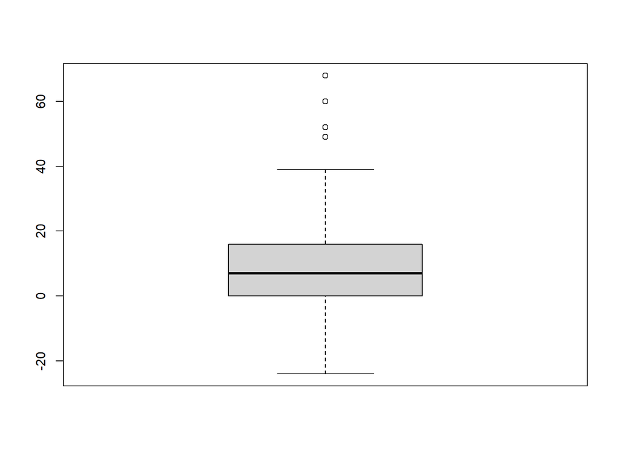

```r
lung_8$wt.loss %>% boxplot()
```

```r
lung_8$wt.loss %>% summary()
```

```
##    Min. 1st Qu.  Median    Mean 3rd Qu.    Max.    NA's
## -24.000   0.000   7.000   9.832  15.750  68.000      14
```

Most patients lost some weight, some quite significant amounts, while others gained weight. We could speculate, that the prognosis differs for people with weight gain vs. no significant wight change vs. weight loss.

Lets bin the data in groups of [min, -5], [-5,5], [5, max]:

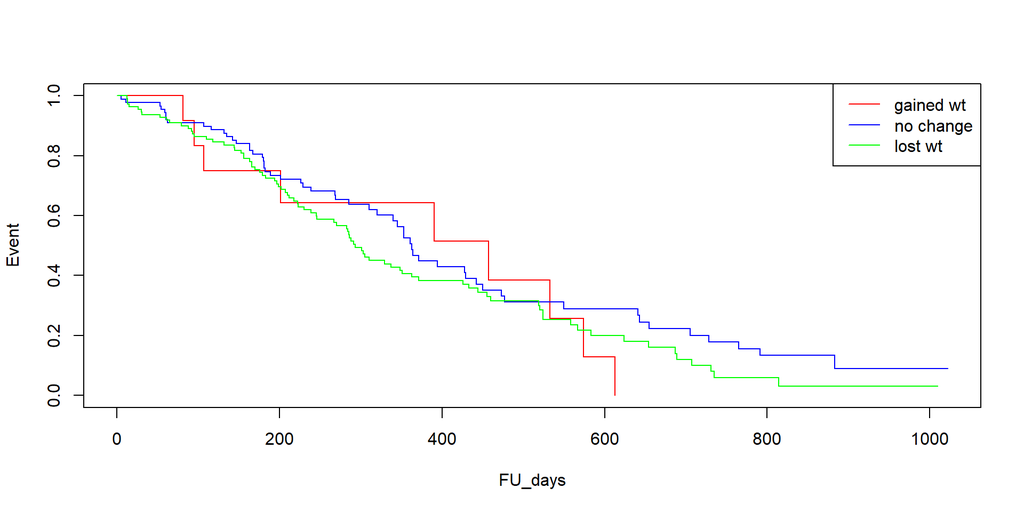

```r
#subset for complete cases
lung_13 <- lung_8[complete.cases(lung_8),]
#bin the data
lung_13 <- lung_13 %>% mutate(wt.loss = cut(wt.loss, breaks = c(-Inf,-5,5, Inf), labels = c("gained_wt", "no change", "lost_wt")))
#plot
plot(survfit(Surv(time = lung_13$time, event = lung_13$status) ~ lung_13$wt.loss), col = c("red", "blue", "green"), xlab = "FU_days", ylab = "Event")
legend("topright", c("gained wt", "no change", "lost wt"), col = c("red", "blue", "green"), lty = "solid")
```

It looks like there is some difference between the no change group and those who lost weight (in the direction we would expect). For the group that gained weight it seems unclear.

Lets try to bin wt.loss by its quartiles:

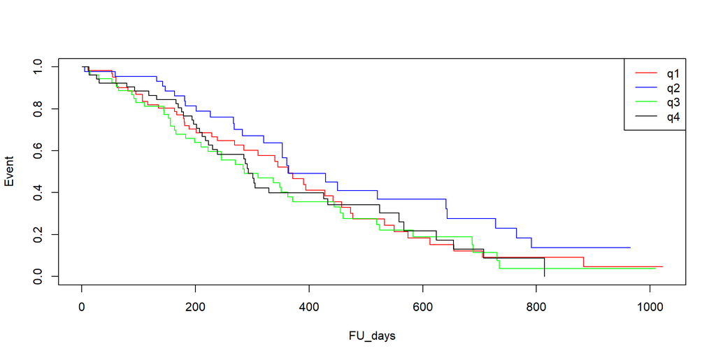

```r
#subset for complete cases
lung_14 <- lung_8[complete.cases(lung_8),]
#bin the data
lung_14 <- lung_14 %>% mutate(wt.loss = cut(wt.loss, breaks = c(-Inf, quantile(wt.loss, prob=c(.25,.5,.75)), Inf)))
#plot
plot(survfit(Surv(time = lung_14$time, event = lung_14$status) ~ lung_14$wt.loss), col = c("red", "blue", "green", "black"), xlab = "FU_days", ylab = "Event")
legend("topright", c("q1", "q2", "q3", "q4"), col = c("red", "blue", "green", "black"), lty = "solid")
```

This doesnt look as expected either. Here moderate weight loss leads to better prognosis than weight gain. This shows, that it is not suited as continuous predictor, as it violates the linearity assumption.

Lets look at the corresponding model:

```r
mcoxrm_14 <- coxph(data = lung_14, Surv(time = lung_14$time, event = lung_14$status) ~ .)
summary(mcoxrm_14)
```

```
## Call:
## coxph(formula = Surv(time = lung_14$time, event = lung_14$status) ~
##     ., data = lung_14)
##
##   n= 210, number of events= 148
##
##                       coef exp(coef)  se(coef)      z Pr(>|z|)
## sexmale           0.575823  1.778593  0.180760  3.186  0.00144 **
## ph.ecog1          0.453399  1.573651  0.214215  2.117  0.03430 *
## ph.ecog2          0.879378  2.409401  0.312222  2.817  0.00485 **
## ph.ecog3          2.359564 10.586335  1.056360  2.234  0.02550 *
## pat.karno        -0.012612  0.987468  0.007489 -1.684  0.09217 .
## wt.loss(0,6.5]   -0.269429  0.763815  0.253797 -1.062  0.28842
## wt.loss(6.5,15]   0.067167  1.069474  0.222742  0.302  0.76300
## wt.loss(15, Inf] -0.455142  0.634358  0.252346 -1.804  0.07129 .
## ---
## Signif. codes:  0 '***' 0.001 '**' 0.01 '*' 0.05 '.' 0.1 ' ' 1
##
##                  exp(coef) exp(-coef) lower .95 upper .95
## sexmale             1.7786    0.56224    1.2480     2.535
## ph.ecog1            1.5737    0.63546    1.0341     2.395
## ph.ecog2            2.4094    0.41504    1.3066     4.443
## ph.ecog3           10.5863    0.09446    1.3353    83.931
## pat.karno           0.9875    1.01269    0.9731     1.002
## wt.loss(0,6.5]      0.7638    1.30922    0.4645     1.256
## wt.loss(6.5,15]     1.0695    0.93504    0.6912     1.655
## wt.loss(15, Inf]    0.6344    1.57640    0.3868     1.040
##
## Concordance= 0.665  (se = 0.026 )
## Likelihood ratio test= 35.27  on 8 df,   p=2e-05
## Wald test            = 36.17  on 8 df,   p=2e-05
## Score (logrank) test = 38.74  on 8 df,   p=5e-06
```

There is no big change in the Concordance. This model would be preferable to the model, where wt.loss is used as continuous variable, since as factor it is not subject to the linearity assumption. However in this model as well the coefficients for wt.loss are not significantly different from zero.

Lets look at the model without wt.loss.

```r
summary(mcoxrm_11)
```

```
## Call:
## coxph(formula = Surv(time = lung_11$time, event = lung_11$status) ~
##     ., data = lung_11)
##
##   n= 226, number of events= 163
##    (2 observations deleted due to missingness)
##
##               coef exp(coef)  se(coef)     z Pr(>|z|)
## sexmale   0.560280  1.751162  0.169411 3.307 0.000942 ***
## ph.ecog1  0.567480  1.763816  0.236676 2.398 0.016498 *
## ph.ecog2  1.253570  3.502824  0.359020 3.492 0.000480 ***
## ph.ecog3  2.455951 11.657518  1.081775 2.270 0.023189 *
## ph.karno  0.011035  1.011096  0.009636 1.145 0.252104
## ---
## Signif. codes:  0 '***' 0.001 '**' 0.01 '*' 0.05 '.' 0.1 ' ' 1
##
##          exp(coef) exp(-coef) lower .95 upper .95
## sexmale      1.751    0.57105    1.2564     2.441
## ph.ecog1     1.764    0.56695    1.1092     2.805
## ph.ecog2     3.503    0.28548    1.7331     7.080
## ph.ecog3    11.658    0.08578    1.3989    97.144
## ph.karno     1.011    0.98903    0.9922     1.030
##
## Concordance= 0.63  (se = 0.025 )
## Likelihood ratio test= 29.79  on 5 df,   p=2e-05
## Wald test            = 30.91  on 5 df,   p=1e-05
## Score (logrank) test = 32.89  on 5 df,   p=4e-06
```

The coefficient for ph.karno is not significantly different from zero.

Lets look at a model using pat.karno instead of ph.karno:

```r
lung_15 <- lung %>% select(!inst & !meal.cal & !age & !ph.karno & !wt.loss)
mcoxrm_15 <- coxph(data = lung_15, Surv(time = lung_15$time, event = lung_15$status) ~ .)
summary(mcoxrm_15)
```

```
## Call:
## coxph(formula = Surv(time = lung_15$time, event = lung_15$status) ~
##     ., data = lung_15)
##
##   n= 224, number of events= 161
##    (4 observations deleted due to missingness)
##
##                coef exp(coef)  se(coef)      z Pr(>|z|)
## sexmale    0.535222  1.707828  0.169692  3.154  0.00161 **
## ph.ecog1   0.399462  1.491023  0.204426  1.954  0.05069 .
## ph.ecog2   0.737284  2.090250  0.281267  2.621  0.00876 **
## ph.ecog3   1.922751  6.839750  1.033612  1.860  0.06285 .
## pat.karno -0.009590  0.990456  0.007153 -1.341  0.18006
## ---
## Signif. codes:  0 '***' 0.001 '**' 0.01 '*' 0.05 '.' 0.1 ' ' 1
##
##           exp(coef) exp(-coef) lower .95 upper .95
## sexmale      1.7078     0.5855    1.2246     2.382
## ph.ecog1     1.4910     0.6707    0.9988     2.226
## ph.ecog2     2.0903     0.4784    1.2044     3.628
## ph.ecog3     6.8397     0.1462    0.9020    51.862
## pat.karno    0.9905     1.0096    0.9767     1.004
##
## Concordance= 0.656  (se = 0.025 )
## Likelihood ratio test= 30.78  on 5 df,   p=1e-05
## Wald test            = 31.72  on 5 df,   p=7e-06
## Score (logrank) test = 33.88  on 5 df,   p=3e-06
```

The coefficient for pat.karno is not significantly different from zero either.

It looks like the model we had fit previously with only sex and ph.ecog is to be preferred over the others we have fit in this section (at least if the goal is inference).